# Predictive mapping of wholesale grain prices for rural areas in Tanzania

Madaga Lavinia, Jordan Chamberlin

19 August, 2024

Suggested citation: Madaga, Lavinia, Jordan Chamberlin, Bisrat Gebrekidan, Robert Hijmans, Nicholaus Kuboja, and Maxwell Mkondiwa. 2024. “Predictive mapping of wholesale grain prices for rural areas in Tanzania.” https://github.com/EiA2030-ex-ante/Tanzania-Price-Data

# Introduction

We are interested in estimating the prices of agricultural food commodities across space and time, on the basis of prices as observed at some market locations. Here we explore methods to model these prices, using monthly data from across Tanzania over the period May 2021-July 2024.

This document describes the process of fitting a Random Forest model to predict these prices. The performance of the Random Forest model is evaluated using Root Mean Square Errors (RMSE) and R-Square as test statistics. We also compare the observed prices with the predicted prices using an out of sample dataset.

# Load Libraries

```r
library(geodata)
library(lubridate)
library(terra)
library(data.table)
library(randomForest)
library(httr)
library(caret)
library(Metrics)
library(pdp)
library(gridExtra)
library(stats)
library(dplyr)
library(stringr)
library(fields)
```

```r
library(corrplot)
library(ggplot2)
```

# Data

This dataset contains price information for various crops across different regions and markets in Tanzania from 2021 to 2024. The data was acquired from Tanzania’s Ministry of Industry and Trade.

```r
setwd("H:/Tanzania Price data/Datasets")

prices <- fread("Tanzania_Price_Data_AllCrops_with_Coordinates4.csv")
dim(prices)
```

```
## [1] 7912   21
```

```r
head(prices)
```

```
##           Region   Market Maize..min.price. Maize..max.price. Rice..min.price.
## 1:        Arusha   Arusha             43000             45000           140000
## 2: Dar es Salaam   Temeke             46000             47000           120000
## 3:        Dodoma  Majengo             45000             50000           132000
## 4:        Dodoma Kibaigwa             30000             42000               NA
## 5:        Kagera   Bukoba             33000             35000           110000
## 6:       Manyara   Babati             30000             45000           120000
##    Rice..max.price. Sorghum..min.price. Sorghum..max.price.
## 1:           170000               60000               65000
## 2:           210000               80000              100000
## 3:           200000               50000               60000
## 4:               NA               45000               48000
## 5:           140000              140000              150000
## 6:           170000               60000               80000
##    Bulrush.Millet..min.price. Bulrush.Millet..max.price.
```

[output cut: 34 more lines]

```r
table(prices$Market)
```

```
##
##       Arusha       Babati      Bariadi     Buguruni       Bukoba        Geita
##          374          243           78           10          390           38
##      Igawilo        Ilala       Iringa     Kibaigwa       Kigoma    Kilombero
##           38          203          392          211          247           38
##    Kinondoni        Lindi      Majengo      Manyara        Mbeya     Mgandini
##          203          246          438          116          117           38
##     Morogoro        Moshi       Mpanda      Mpimbwe       Mtwara       Musoma
##          386          252          195           39          400          287
## Mwananyamala       Mwanza       Namfua       Njombe    Nyankumbu        Pwani
##           38          349           38          174           38           78
##    Shinyanga      Singida       Songea       Songwe   Sumbawanga       Tabora
##          282           83          361           48          385          364
##      Tandale      Tandika        Tanga       Temeke       Ubungo
##           55           64          361          169           46
```

```r
sapply(prices, class)
```

```
##                     Region                     Market
##                "character"                "character"
##          Maize..min.price.          Maize..max.price.
##                  "integer"                  "integer"
##           Rice..min.price.           Rice..max.price.
##                  "integer"                  "integer"
##        Sorghum..min.price.        Sorghum..max.price.
##                  "integer"                  "integer"
## Bulrush.Millet..min.price. Bulrush.Millet..max.price.
##                  "integer"                  "integer"
##  Finger.Millet..min.price.  Finger.Millet..max.price.
##                  "integer"                  "integer"
##          Wheat..min.price.          Wheat..max.price.
##                  "integer"                  "integer"
##          Beans..min.price.          Beans..max.price.
##                  "integer"                  "integer"
## Irish.Potatoes..min.price. Irish.Potatoes..max.price.
##                  "integer"                  "integer"
##                       Date                   Latitude
##                "character"                  "numeric"
##                  Longitude
##                  "numeric"
```

```r
# Convert to date format
prices$Date <- lubridate::mdy(prices$Date)
```

## Basic Data preperation

Check the Region and Market names and coodinates. Make sure the Region and Market names are harmonized and properly geocoded

```r
unique(prices[Region=="Arusha",.(Market, Latitude, Longitude)])
```

```
##       Market Latitude Longitude
## 1:    Arusha -3.36968  36.68808
## 2: Kilombero -3.37324  36.67870
```

```r
unique(prices[Region=="Dar es Salaam",.(Market, Latitude, Longitude)])
```

```
##          Market  Latitude Longitude
## 1:       Temeke -6.850970  39.25672
## 2:    Kinondoni -6.784070  39.27007
## 3:        Ilala -6.829410  39.26289
## 4:      Tandika -6.867912  39.25480
## 5:     Buguruni -6.838380  39.24359
## 6:      Tandale -6.795230  39.24085
## 7:       Ubungo -6.793620  39.20966
## 8: Mwananyamala -6.788890  39.25840
```

```r
unique(prices[Region=="Dodoma",.(Market, Latitude, Longitude)])
```

```
##      Market Latitude Longitude
## 1:  Majengo -6.17971  35.74109
## 2: Kibaigwa -6.08110  36.64645
```

```r
unique(prices[Region=="Kagera",.(Market, Latitude, Longitude)])
```

```
##    Market Latitude Longitude
## 1: Bukoba  -1.3314  31.81293
```

```r
unique(prices[Region=="Manyara",.(Market, Latitude, Longitude)])
```

```
##     Market Latitude Longitude
## 1:  Babati -4.21006  35.74915
## 2: Manyara -4.46011  37.20217
```

```r
unique(prices[Region=="Rukwa",.(Market, Latitude, Longitude)])
```

```
##        Market Latitude Longitude
## 1: Sumbawanga -7.95239  31.62319
```

```r
unique(prices[Region=="Mpanda",.(Market, Latitude, Longitude)])
```

```
## Empty data.table (0 rows and 3 cols): Market,Latitude,Longitude
```

```r
unique(prices[Region=="Mtwara",.(Market, Latitude, Longitude)])
```

```
##    Market  Latitude Longitude
## 1: Mtwara -10.28009  40.18191
```

```r
unique(prices[Region=="Tabora",.(Market, Latitude, Longitude)])
```

```
##    Market Latitude Longitude
## 1: Tabora -5.01972  32.80767
```

```r
unique(prices[Region=="Tanga",.(Market, Latitude, Longitude)])
```

```
##      Market  Latitude Longitude
## 1:    Tanga -5.074260  39.09993
## 2: Mgandini -5.086235  39.09561
```

```r
unique(prices[Region=="Iringa",.(Market, Latitude, Longitude)])
```

```
##    Market Latitude Longitude
## 1: Iringa -7.78001  35.69671
```

```r
unique(prices[Region=="Kigoma",.(Market, Latitude, Longitude)])
```

```
##    Market Latitude Longitude
## 1: Kigoma -4.89697  29.65987
```

```r
unique(prices[Region=="Morogoro",.(Market, Latitude, Longitude)])
```

```
##      Market Latitude Longitude
## 1: Morogoro -6.82771  37.66542
```

```r
unique(prices[Region=="Mwanza",.(Market, Latitude, Longitude)])
```

```
##    Market Latitude Longitude
## 1: Mwanza -2.51969  32.90144
```

```r
unique(prices[Region=="Mara",.(Market, Latitude, Longitude)])
```

```
##    Market Latitude Longitude
## 1: Musoma -1.49982   33.8083
```

```r
unique(prices[Region=="Ruvuma",.(Market, Latitude, Longitude)])
```

```
##    Market  Latitude Longitude
## 1: Songea -10.67873  35.64836
```

```r
unique(prices[Region=="Shinyanga",.(Market, Latitude, Longitude)])
```

```
##       Market Latitude Longitude
## 1: Shinyanga -3.67226  33.43069
```

```r
unique(prices[Region=="Kilimanjaro",.(Market, Latitude, Longitude)])
```

```
##    Market Latitude Longitude
## 1:  Moshi -3.34865  37.34352
```

```r
unique(prices[Region=="Mbeya",.(Market, Latitude, Longitude)])
```

```
##     Market  Latitude Longitude
## 1:   Mbeya -8.909940  33.45517
## 2: Igawilo -8.924246  33.56788
```

```r
unique(prices[Region=="Katavi",.(Market, Latitude, Longitude)])
```

```
##     Market Latitude Longitude
## 1:  Mpanda -6.34295  31.07299
## 2: Mpimbwe -7.24425  31.81782
## 3: Majengo -6.34809  31.07055
```

```r
unique(prices[Region=="Njombe",.(Market, Latitude, Longitude)])
```

```
##    Market Latitude Longitude
## 1: Njombe -9.33805  34.76949
```

```r
unique(prices[Region=="Lindi",.(Market, Latitude, Longitude)])
```

```
##    Market Latitude Longitude
## 1:  Lindi   -9.995    39.708
```

```r
unique(prices[Region=="Singida",.(Market, Latitude, Longitude)])
```

```
##     Market  Latitude Longitude
## 1: Singida -4.812610   34.7428
## 2:  Namfua -4.821121   34.7470
```

```r
unique(prices[Region=="Pwani",.(Market, Latitude, Longitude)])
```

```
##    Market Latitude Longitude
## 1:  Pwani -6.44221  38.90622
```

```r
unique(prices[Region=="Simiyu",.(Market, Latitude, Longitude)])
```

```
##     Market Latitude Longitude
## 1: Bariadi -2.80355  33.98699
```

```r
unique(prices[Region=="Geita",.(Market, Latitude, Longitude)])
```

```
##       Market  Latitude Longitude
## 1:     Geita -2.870760  32.23408
## 2: Nyankumbu -2.895955  32.22871
```

```r
unique(prices[Region=="Songwe",.(Market, Latitude, Longitude)])
```

```
##    Market Latitude Longitude
## 1: Songwe -8.95179  33.24377
```

```r
setnames(prices, old = "Maize..min.price.", new = "mai.price.min")
setnames(prices, old = "Rice..min.price.", new = "ric.price.min")
setnames(prices, old = "Sorghum..min.price.", new = "sor.price.min")
setnames(prices, old = "Bulrush.Millet..min.price.", new = "bul.price.min")
setnames(prices, old = "Finger.Millet..min.price.", new = "fin.price.min")
setnames(prices, old = "Wheat..min.price.", new = "whe.price.min")
setnames(prices, old = "Beans..min.price.", new = "bea.price.min")
setnames(prices, old = "Irish.Potatoes..min.price.", new = "pot.price.min")
setnames(prices, old = "Maize..max.price.", new = "mai.price.max")
setnames(prices, old = "Rice..max.price.", new = "ric.price.max")
setnames(prices, old = "Sorghum..max.price.", new = "sor.price.max")
setnames(prices, old = "Bulrush.Millet..max.price.", new = "bul.price.max")
setnames(prices, old = "Finger.Millet..max.price.", new = "fin.price.max")
setnames(prices, old = "Wheat..max.price.", new = "whe.price.max")
setnames(prices, old = "Beans..max.price.", new = "bea.price.max")
setnames(prices, old = "Irish.Potatoes..max.price.", new = "pot.price.max")
```

```r
sapply(prices, class)
```

```
##        Region        Market mai.price.min mai.price.max ric.price.min
##   "character"   "character"     "integer"     "integer"     "integer"
## ric.price.max sor.price.min sor.price.max bul.price.min bul.price.max
##     "integer"     "integer"     "integer"     "integer"     "integer"
## fin.price.min fin.price.max whe.price.min whe.price.max bea.price.min
##     "integer"     "integer"     "integer"     "integer"     "integer"
## bea.price.max pot.price.min pot.price.max          Date      Latitude
##     "integer"     "integer"     "integer"        "Date"     "numeric"
##     Longitude
##     "numeric"
```

```r
#convert prices to numeric
prices$mai.price.min <- as.numeric(prices$mai.price.min)
prices$ric.price.min <- as.numeric(prices$ric.price.min)
prices$sor.price.min <- as.numeric(prices$sor.price.min)
prices$bul.price.min <- as.numeric(prices$bul.price.min)
prices$fin.price.min <- as.numeric(prices$fin.price.min)
prices$whe.price.min <- as.numeric(prices$whe.price.min)
prices$bea.price.min <- as.numeric(prices$bea.price.min)
prices$pot.price.min <- as.numeric(prices$pot.price.min)

prices$mai.price.max <- as.numeric(prices$mai.price.max)
prices$ric.price.max <- as.numeric(prices$ric.price.max)
prices$sor.price.max <- as.numeric(prices$sor.price.max)
prices$bul.price.max <- as.numeric(prices$bul.price.max)
prices$fin.price.max <- as.numeric(prices$fin.price.max)
prices$whe.price.max <- as.numeric(prices$whe.price.max)
prices$bea.price.max <- as.numeric(prices$bea.price.max)
prices$pot.price.max <- as.numeric(prices$pot.price.max)

sapply(prices, class)
```

```
##        Region        Market mai.price.min mai.price.max ric.price.min
##   "character"   "character"     "numeric"     "numeric"     "numeric"
## ric.price.max sor.price.min sor.price.max bul.price.min bul.price.max
##     "numeric"     "numeric"     "numeric"     "numeric"     "numeric"
## fin.price.min fin.price.max whe.price.min whe.price.max bea.price.min
##     "numeric"     "numeric"     "numeric"     "numeric"     "numeric"
## bea.price.max pot.price.min pot.price.max          Date      Latitude
##     "numeric"     "numeric"     "numeric"        "Date"     "numeric"
##     Longitude
##     "numeric"
```

```r
# convert to price per kg
prices$mai.price.min <- prices$mai.price.min/100
prices$ric.price.min <- prices$ric.price.min/100
prices$sor.price.min <- prices$sor.price.min/100
prices$bul.price.min <- prices$bul.price.min/100
prices$fin.price.min <- prices$fin.price.min/100
prices$whe.price.min <- prices$whe.price.min/100
prices$bea.price.min <- prices$bea.price.min/100
prices$pot.price.min <- prices$pot.price.min/100

prices$mai.price.max <- prices$mai.price.max/100
prices$ric.price.max <- prices$ric.price.max/100
prices$sor.price.max <- prices$sor.price.max/100
prices$bul.price.max <- prices$bul.price.max/100
prices$fin.price.max <- prices$fin.price.max/100
prices$whe.price.max <- prices$whe.price.max/100
prices$bea.price.max <- prices$bea.price.max/100
prices$pot.price.max <- prices$pot.price.max/100
```

```r
# calculate average of min and max
prices$mai.price <- (prices$mai.price.min + prices$mai.price.max) / 2
prices$ric.price <- (prices$ric.price.min + prices$ric.price.max) / 2
prices$sor.price <- (prices$sor.price.min + prices$sor.price.max) / 2
prices$bul.price <- (prices$bul.price.min + prices$bul.price.max) / 2
prices$fin.price <- (prices$fin.price.min + prices$fin.price.max) / 2
prices$whe.price <- (prices$whe.price.min + prices$whe.price.max) / 2
prices$bea.price <- (prices$bea.price.min + prices$bea.price.max) / 2
prices$pot.price <- (prices$pot.price.min + prices$pot.price.max) / 2
```

```r
#We can add dates by using the year and the month names
prices$Day   <- day(prices$Date)
prices$Month <- month(prices$Date)
prices$Year  <- year(prices$Date)
```

```r
# drop unneccessary columns
prices <- prices[,!c("mai.price.min", "mai.price.max",
                     "ric.price.min", "ric.price.max",
                     "sor.price.min", "sor.price.max",
                     "bul.price.min", "bul.price.max",
                     "fin.price.min", "fin.price.max",
                     "whe.price.min", "whe.price.max",
                     "bea.price.min", "bea.price.max",
                     "pot.price.min", "pot.price.max")]
```

```r
# calculate monthly mean prices by market
prices.monthly <- prices[, .(mai.price = mean(mai.price, na.rm = TRUE),
           ric.price = mean(ric.price, na.rm = TRUE),
           sor.price = mean(sor.price, na.rm = TRUE),
           bul.price = mean(bul.price, na.rm = TRUE),
           fin.price = mean(fin.price, na.rm = TRUE),
           whe.price = mean(whe.price, na.rm = TRUE),
           bea.price = mean(bea.price, na.rm = TRUE),
           pot.price = mean(pot.price, na.rm = TRUE)),
       by=.(Region, Market, Month, Year, Latitude, Longitude)]
```

```r
# reshape to long (so that prices for different commodities can be simultaneously estimated)
prices.monthly
```

```
##             Region     Market Month Year Latitude Longitude mai.price ric.price
##   1:        Arusha     Arusha     5 2021 -3.36968  36.68808  469.0000  1530.000
##   2: Dar es Salaam     Temeke     5 2021 -6.85097  39.25672  485.0000  1650.000
##   3:        Dodoma    Majengo     5 2021 -6.17971  35.74109  501.5000  1592.000
##   4:        Dodoma   Kibaigwa     5 2021 -6.08110  36.64645  375.0000       NaN
##   5:        Kagera     Bukoba     5 2021 -1.33140  31.81293  426.2500  1260.000
##  ---
## 860:        Mwanza     Mwanza     7 2024 -2.51969  32.90144  725.0000  2350.000
## 861:         Pwani      Pwani     7 2024 -6.44221  38.90622  835.7143  1946.429
## 862:        Simiyu    Bariadi     7 2024 -2.80355  33.98699  660.0000  1450.000
## 863:        Kigoma     Kigoma     7 2024 -4.89697  29.65987  578.5714  1417.857
## 864:         Rukwa Sumbawanga     7 2024 -7.95239  31.62319  546.7857  1653.571
##      sor.price bul.price fin.price whe.price bea.price pot.price
##   1:   695.000   761.000  1333.000  793.0000  1545.000  745.0000
##   2:   900.000   900.000  1775.000 1230.0000  2420.000  730.0000
##   3:   558.000   581.000  1752.000       NaN  2075.000  618.0000
##   4:   437.500       NaN       NaN       NaN       NaN       NaN
##   5:  1375.000  1337.500  1637.500 1637.5000  1300.000  675.0000
##  ---
## 860:  1428.571  1421.429  1621.429       NaN  2528.571 1142.8571
## 861:  1442.857  1550.000  1857.143 1975.0000  2967.857 1735.7143
## 862:  1400.000  1739.286  1728.571 2457.1429  2750.000 1500.0000
## 863:  1821.429  1892.857  1907.143 1867.8571  2228.571 1075.0000
## 864:       NaN       NaN   975.000  719.6429  2135.714  641.0714
```

```r
prices.monthly.long <- melt(prices.monthly, id.vars=c('Region', 'Market', 'Month', 'Year', 'Latitude', 'Longitude'),)
```

```r
# rename columns
setnames(prices.monthly.long, old="variable", new="Crop")
setnames(prices.monthly.long, old="value", new="pkg")
```

```r
# replace crop names
prices.monthly.long[Crop == "mai.price", Crop := "Maize"]
prices.monthly.long[Crop == "ric.price", Crop := "Rice"]
prices.monthly.long[Crop == "sor.price", Crop := "Sorghum"]
prices.monthly.long[Crop == "bul.price", Crop := "B.Millet"]
prices.monthly.long[Crop == "fin.price", Crop := "F.Millet"]
prices.monthly.long[Crop == "whe.price", Crop := "Wheat"]
prices.monthly.long[Crop == "bea.price", Crop := "Beans"]
prices.monthly.long[Crop == "pot.price", Crop := "Potato"]
```

```r
# Reset the factor levels to updated levels
prices.monthly.long[, Crop := factor(Crop)]
# Check the unique values again
unique(prices.monthly.long$Crop)
```

```
## [1] Maize    Rice     Sorghum  B.Millet F.Millet Wheat    Beans    Potato
## Levels: Maize Rice Sorghum B.Millet F.Millet Wheat Beans Potato
```

```r
# generate dummies to use in place of factors (for later spatial predictions, which are struggling with factors)
prices.monthly.long[, maize   := ifelse(Crop == "Maize",1,0)]
prices.monthly.long[, rice    := ifelse(Crop == "Rice",1,0)]
prices.monthly.long[, sorghum := ifelse(Crop == "Sorghum",1,0)]
prices.monthly.long[, bmillet := ifelse(Crop == "B.Millet",1,0)]
prices.monthly.long[, fmillet := ifelse(Crop == "F.Millet",1,0)]
prices.monthly.long[, wheat   := ifelse(Crop == "Wheat",1,0)]
prices.monthly.long[, beans   := ifelse(Crop == "Beans",1,0)]
prices.monthly.long[, potato  := ifelse(Crop == "Potato",1,0)]
```

```r
prices.monthly.long[, jan := ifelse(Month == 1  , 1, 0)]
prices.monthly.long[, feb := ifelse(Month == 2  , 1, 0)]
prices.monthly.long[, mar := ifelse(Month == 3  , 1, 0)]
prices.monthly.long[, apr := ifelse(Month == 4  , 1, 0)]
prices.monthly.long[, may := ifelse(Month == 5  , 1, 0)]
prices.monthly.long[, jun := ifelse(Month == 6  , 1, 0)]
prices.monthly.long[, jul := ifelse(Month == 7  , 1, 0)]
prices.monthly.long[, aug := ifelse(Month == 8  , 1, 0)]
prices.monthly.long[, sep := ifelse(Month == 9  , 1, 0)]
prices.monthly.long[, oct := ifelse(Month == 10 , 1, 0)]
prices.monthly.long[, nov := ifelse(Month == 11 , 1, 0)]
prices.monthly.long[, dec := ifelse(Month == 12 , 1, 0)]
```

```r
# replace NaN with NAs in the price observations
prices.monthly.long[is.nan(pkg), pkg := NA]
# Remove observations with missing observations
prices.monthly.long <- na.omit(prices.monthly.long)
```

```r
# bring in raster stack as predictors
geodata_path("H:/Tanzania Price data/Datasets/geodata")
list.files("H:/Tanzania Price data/Datasets/geodata", recursive=TRUE)
```

```
##  [1] "climate/wc2.1_country/TZA_wc2.1_30s_bio.tif"
##  [2] "travel/travel_time_to_cities_u5.tif"
##  [3] "TRUE/gadm/gadm41_TZA_0_pk.rds"
##  [4] "TRUE/gadm/gadm41_TZA_1_pk.rds"
##  [5] "TRUE/gadm/gadm41_TZA_2_pk.rds"
##  [6] "TRUE/gadm/gadm41_TZA_3_pk.rds"
##  [7] "TRUE/spam/spam2017v2r1_ssa_area.zip"
##  [8] "TRUE/spam/spam2017V2r1_SSA_H_MAIZ_A.tif"
##  [9] "TRUE/spam/spam2017V2r1_SSA_H_MAIZ_H.tif"
## [10] "TRUE/spam/spam2017V2r1_SSA_H_MAIZ_I.tif"
## [11] "TRUE/spam/spam2017V2r1_SSA_H_MAIZ_L.tif"
## [12] "TRUE/spam/spam2017V2r1_SSA_H_MAIZ_R.tif"
## [13] "TRUE/spam/spam2017V2r1_SSA_H_MAIZ_S.tif"
## [14] "TRUE/spam/spam2017V2r1_SSA_Y_MAIZ_A.tif"
## [15] "TRUE/spam/spam2017V2r1_SSA_Y_MAIZ_H.tif"
## [16] "TRUE/spam/spam2017V2r1_SSA_Y_MAIZ_I.tif"
## [17] "TRUE/spam/spam2017V2r1_SSA_Y_MAIZ_L.tif"
## [18] "TRUE/spam/spam2017V2r1_SSA_Y_MAIZ_R.tif"
## [19] "TRUE/spam/spam2017V2r1_SSA_Y_MAIZ_S.tif"
## [20] "TRUE/spam/spam2017v2r1_ssa_yield.zip"
## [21] "TRUE/travel/travel_time_to_cities_u5.tif"
## [22] "TRUE/travel/travel_time_to_ports_1.tif"
## [23] "TRUE/wc2.1_country/TZA_wc2.1_30s_bio.tif"
```

```r
# tza0 <- gadm(country="TZA", level=0)
# tza1 <- gadm(country="TZA", level=1)
# tza2 <- gadm(country="TZA", level=2)
# tza3 <- gadm(country="TZA", level=3)

tza0 <- readRDS("H:/Tanzania Price data/Datasets/geodata/TRUE/gadm/gadm41_TZA_0_pk.rds")
tza1 <- readRDS("H:/Tanzania Price data/Datasets/geodata/TRUE/gadm/gadm41_TZA_1_pk.rds")
tza2 <- readRDS("H:/Tanzania Price data/Datasets/geodata/TRUE/gadm/gadm41_TZA_2_pk.rds")
tza3 <- readRDS("H:/Tanzania Price data/Datasets/geodata/TRUE/gadm/gadm41_TZA_3_pk.rds")
```

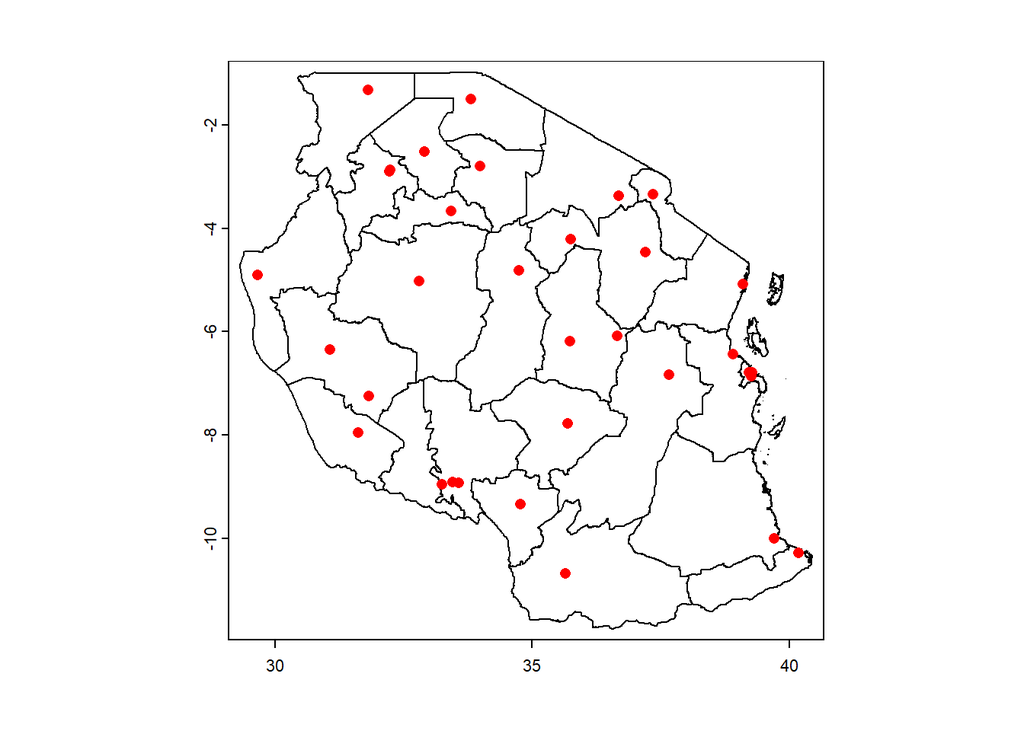

```r
# convert prices observations to vector for mapping
mypts <- vect(prices.monthly.long, geom=c("Longitude", "Latitude"), crs=crs(tza0), keepgeom=TRUE)

# see if these show up correctly
plot(tza1)
plot(mypts, col="Red", add=TRUE)
```

```r
# text(mypts, label="Market")
```

```r
# create reference raster
tza_extent <- ext(tza1) |> floor()
r <- crop(rast(res=1/12), tza_extent)
```

# Interpolate

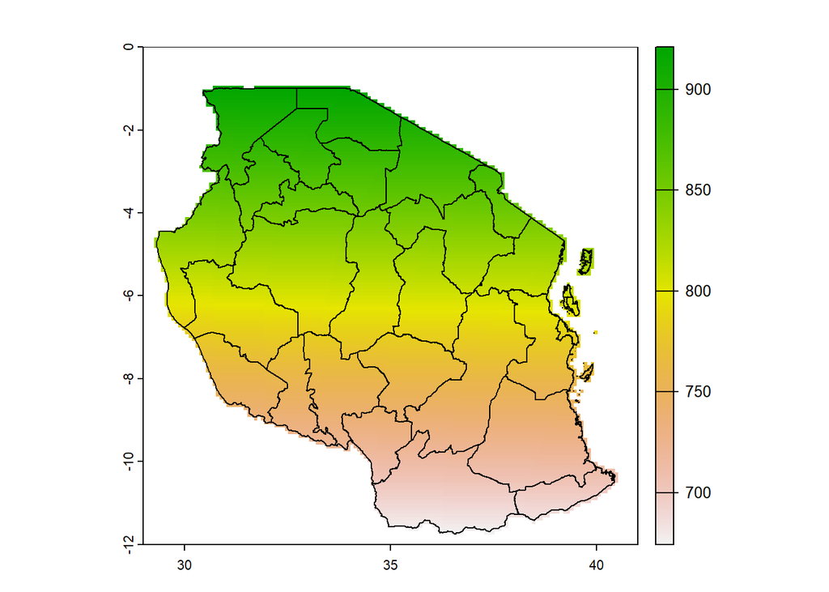

```r
## Interpolate

#xy <- as.matrix(mypts[,c("Longitude", "Latitude")])
xy <- geom(mypts)[,c("y","x")]
#tps <- Tps(xy, p$spatial)
tps <- Tps(xy, mypts$pkg)
sp <- interpolate(r, tps)
sp <- mask(sp, tza1)
plot(sp)
lines(tza1)
```

## Predict prices with coodinates only

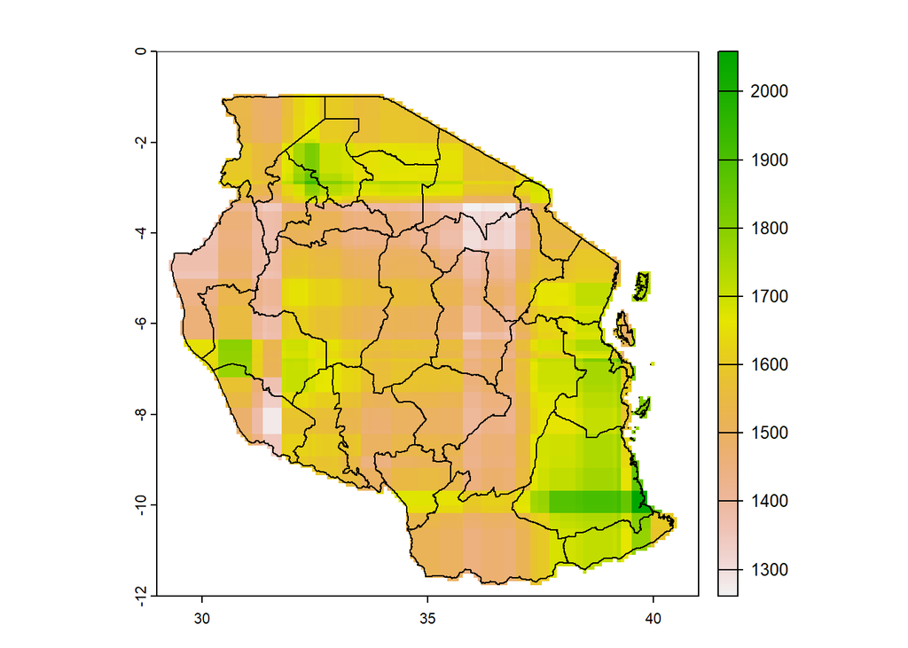

```r
rf <- randomForest(pkg ~ Longitude + Latitude , data=mypts)
sp3 <- interpolate(r, rf, xyNames=c("Longitude", "Latitude"))
sp3 <- mask(sp3, tza1)
plot(sp3)
lines(tza1)
```

## Covariates

The covariates used include a mix of crop-specific indicators, temporal variables to capture monthly and yearly effects, geographical coordinates, accessibility measures, climatic conditions, and lagged rainfall to account for delayed effects of weather on crop prices.

```r
ttcity <- rast("H:/Tanzania Price data/Datasets/geodata/TRUE/travel/travel_time_to_cities_u5.tif")
ttport <- rast("H:/Tanzania Price data/Datasets/geodata/TRUE/travel/travel_time_to_ports_1.tif")
clm    <- rast("H:/Tanzania Price data/Datasets/geodata/TRUE/wc2.1_country/TZA_wc2.1_30s_bio.tif")
area   <- rast("H:/Tanzania Price data/Datasets/geodata/TRUE/spam/spam2017V2r1_SSA_H_MAIZ_A.tif")
yield  <- rast("H:/Tanzania Price data/Datasets/geodata/TRUE/spam/spam2017V2r1_SSA_Y_MAIZ_R.tif")
popd  <- rast("gpw_v4_population_density_rev11_2020_10m.tif")
```

```r
names(ttcity) <- c("ttcity_u5") ## travel time cities of 100k or more
names(ttport) <- c("ttport_1") ## travel time to major ports
names(clm) <- gsub("wc2.1_30s_", "", names(clm))
names(area) <- c("MAI_ARE") # SPAM maize area 2010
names(yield)  <- c("MAI_YLD") # SPAM maize yield 2010
names(popd)  <- c("popdens") # GPW4

comment(ttcity) <- "travel time to cities 100k or more"
comment(ttport) <- "travel time to major ports"

comment(popd) <- "population density 2020 (GPW4 @ 10dm)"

comment(clm)[1] <-"BIO1 = Annual Mean Temperature"
comment(clm)[2] <-"BIO2 = Mean Diurnal Range (Mean of monthly (max temp - min temp))"
comment(clm)[3] <-"BIO3 = Isothermality (BIO2/BIO7) (×100)"
comment(clm)[4] <-"BIO4 = Temperature Seasonality (standard deviation ×100)"
comment(clm)[5] <-"BIO5 = Max Temperature of Warmest Month"
comment(clm)[6] <-"BIO6 = Min Temperature of Coldest Month"
comment(clm)[7] <-"BIO7 = Temperature Annual Range (BIO5-BIO6)"
comment(clm)[8] <-"BIO8 = Mean Temperature of Wettest Quarter"
comment(clm)[9] <-"BIO9 = Mean Temperature of Driest Quarter"
comment(clm)[10] <-"BIO10 = Mean Temperature of Warmest Quarter"
comment(clm)[11] <-"BIO11 = Mean Temperature of Coldest Quarter"
comment(clm)[12] <-"BIO12 = Annual Precipitation"
comment(clm)[13] <-"BIO13 = Precipitation of Wettest Month"
comment(clm)[14] <-"BIO14 = Precipitation of Driest Month"
comment(clm)[15] <-"BIO15 = Precipitation Seasonality (Coefficient of Variation)"
comment(clm)[16] <-"BIO16 = Precipitation of Wettest Quarter"
comment(clm)[17] <-"BIO17 = Precipitation of Driest Quarter"
comment(clm)[18] <-"BIO18 = Precipitation of Warmest Quarter"
comment(clm)[19] <-"BIO19 = Precipitation of Coldest Quarter"
```

## Harmonize rasters to national boundaries and common resolution

```r
ttcity <- resample(ttcity, r)
ttport <- resample(ttport, r)
clm    <- resample(clm, r)
area   <- resample(area, r)
popd   <- resample(popd, r)
freq(is.na(area))
```

```
##   layer value count
## 1     1     0 14393
## 2     1     1  6343
```

```r
area <- classify(area, cbind(NA,0))
yield  <- resample(yield, r)
freq(is.na(yield))
```

```
##   layer value count
## 1     1     0 14393
## 2     1     1  6343
```

```r
yield <- classify(yield, cbind(NA,0))
# check again
compareGeom(ttcity, ttport, clm, area, yield, popd)
```

```
## [1] TRUE
```

## Generate Latitude and Longitude grid

```r
latgrd <- longrd <- r
latgrd[] <- yFromCell(latgrd, 1:ncell(latgrd))
longrd[] <- xFromCell(longrd, 1:ncell(longrd))
names(latgrd) <- c("latitude")
names(longrd) <- c("longitude")
```

## Prepare Predictor Stack

```r
rstack <- c(ttcity, ttport, clm, area, yield, popd, latgrd, longrd)
names(rstack)
```

```
##  [1] "ttcity_u5" "ttport_1"  "bio_1"     "bio_2"     "bio_3"     "bio_4"
##  [7] "bio_5"     "bio_6"     "bio_7"     "bio_8"     "bio_9"     "bio_10"
## [13] "bio_11"    "bio_12"    "bio_13"    "bio_14"    "bio_15"    "bio_16"
## [19] "bio_17"    "bio_18"    "bio_19"    "MAI_ARE"   "MAI_YLD"   "popdens"
## [25] "latitude"  "longitude"
```

```r
# create focal mean to extract from (as alternative to using buffers for extraction, which are not supported in terra)
fm <- focalMat(r, d=0.18, type='circle', fillNA=FALSE)
rstack2 <- focal(rstack, w=fm, fun="mean", na.policy="all", fillvalue=NA, # na.rm=TRUE,
                 expand=TRUE, silent=FALSE) #, filename="", overwrite=FALSE)
```

```r
# extract values to dataset -- use a 20km buffer
# do a focal sum of 20km radius  - this is about 0.18 of a decimal degree... 0.18*112=20.16
fm <- focalMat(r, d=0.18, type='circle', fillNA=FALSE)
rstack2 <- focal(rstack2, w=fm, fun="sum", na.policy="all", fillvalue=NA, na.rm=TRUE,
                 expand=TRUE, silent=FALSE) #, filename="", overwrite=FALSE)
```

# Lag Rainfall

## Bring in Rainfall Data from Chirps

```r
chirps_path <- "H:/Tanzania Price data/chirps_data"

chirps_files <- list.files(chirps_path, pattern = ".tif$", full.names = TRUE)

# Read all CHIRPS data files into a SpatRaster collection
chirps_rasters <- rast(chirps_files)

#crop to Tanzania boundary
Chirps_Tz <- crop(chirps_rasters, tza1)

writeRaster(Chirps_Tz, "Tz_chirps_monthly_croped.tif", overwrite=TRUE)

Tz_chirps_monthly <- terra::rast("Tz_chirps_monthly_croped.tif")
Tz_chirps_monthly
```

```
## class       : SpatRaster
## dimensions  : 215, 222, 45  (nrow, ncol, nlyr)
## resolution  : 0.05, 0.05  (x, y)
## extent      : 29.35, 40.45, -11.75, -1.000001  (xmin, xmax, ymin, ymax)
## coord. ref. : lon/lat WGS 84 (EPSG:4326)
## source      : Tz_chirps_monthly_croped.tif
## names       : chirp~20.11, chirp~20.12, chirp~21.01, chirp~21.02, chirp~21.03, chirp~21.04, ...
## min values  :  -9999.0000,  -9999.0000,   -9999.000,  -9999.0000,  -9999.0000,  -9999.0000, ...
## max values  :    459.7112,    504.3329,     508.448,    585.3241,    750.1949,    960.3376, ...
```

```r
#Replace -9999 with NA
Tz_chirps_monthly <- classify(Tz_chirps_monthly, cbind(-9999,NA))

#extract layer names
layer_names <- names(Tz_chirps_monthly)
layer_names
```

```
##  [1] "chirps-v2.0.2020.11" "chirps-v2.0.2020.12" "chirps-v2.0.2021.01"
##  [4] "chirps-v2.0.2021.02" "chirps-v2.0.2021.03" "chirps-v2.0.2021.04"
##  [7] "chirps-v2.0.2021.05" "chirps-v2.0.2021.06" "chirps-v2.0.2021.07"
## [10] "chirps-v2.0.2021.08" "chirps-v2.0.2021.09" "chirps-v2.0.2021.10"
## [13] "chirps-v2.0.2021.11" "chirps-v2.0.2021.12" "chirps-v2.0.2022.01"
## [16] "chirps-v2.0.2022.02" "chirps-v2.0.2022.03" "chirps-v2.0.2022.04"
## [19] "chirps-v2.0.2022.05" "chirps-v2.0.2022.06" "chirps-v2.0.2022.07"
## [22] "chirps-v2.0.2022.08" "chirps-v2.0.2022.09" "chirps-v2.0.2022.10"
## [25] "chirps-v2.0.2022.11" "chirps-v2.0.2022.12" "chirps-v2.0.2023.01"
## [28] "chirps-v2.0.2023.02" "chirps-v2.0.2023.03" "chirps-v2.0.2023.04"
## [31] "chirps-v2.0.2023.05" "chirps-v2.0.2023.06" "chirps-v2.0.2023.07"
## [34] "chirps-v2.0.2023.08" "chirps-v2.0.2023.09" "chirps-v2.0.2023.10"
## [37] "chirps-v2.0.2023.11" "chirps-v2.0.2023.12" "chirps-v2.0.2024.01"
## [40] "chirps-v2.0.2024.02" "chirps-v2.0.2024.03" "chirps-v2.0.2024.04"
## [43] "chirps-v2.0.2024.05" "chirps-v2.0.2024.06" "chirps-v2.0.2024.07"
```

```r
# We need to create a sequence of dates from the layer names
# Extract year and month from layer names and convert to Date
dates <- as.Date(paste0(sub("chirps-v2.0\\.", "", layer_names), "-01"), format = "%Y.%m-%d")
dates
```

```
##  [1] "2020-11-01" "2020-12-01" "2021-01-01" "2021-02-01" "2021-03-01"
##  [6] "2021-04-01" "2021-05-01" "2021-06-01" "2021-07-01" "2021-08-01"
## [11] "2021-09-01" "2021-10-01" "2021-11-01" "2021-12-01" "2022-01-01"
## [16] "2022-02-01" "2022-03-01" "2022-04-01" "2022-05-01" "2022-06-01"
## [21] "2022-07-01" "2022-08-01" "2022-09-01" "2022-10-01" "2022-11-01"
## [26] "2022-12-01" "2023-01-01" "2023-02-01" "2023-03-01" "2023-04-01"
## [31] "2023-05-01" "2023-06-01" "2023-07-01" "2023-08-01" "2023-09-01"
## [36] "2023-10-01" "2023-11-01" "2023-12-01" "2024-01-01" "2024-02-01"
## [41] "2024-03-01" "2024-04-01" "2024-05-01" "2024-06-01" "2024-07-01"
```

```r
# Assign these dates to the SpatRaster object
time(Tz_chirps_monthly) <- dates

#rename the layers to the formatted dates
names(Tz_chirps_monthly) <- dates

# Check the SpatRaster object
print(Tz_chirps_monthly)
```

```
## class       : SpatRaster
## dimensions  : 215, 222, 45  (nrow, ncol, nlyr)
## resolution  : 0.05, 0.05  (x, y)
## extent      : 29.35, 40.45, -11.75, -1.000001  (xmin, xmax, ymin, ymax)
## coord. ref. : lon/lat WGS 84 (EPSG:4326)
## source(s)   : memory
## varname     : Tz_chirps_monthly_croped
## names       : 2020-11-01, 2020-12-01,  2021-01-01,  2021-02-01,  2021-03-01, 2021-04-01, ...
## min values  :   5.859746,   1.903993,   0.8161677,   0.3187093,   0.9539621,    1.17571, ...
## max values  : 459.711212, 504.332947, 508.4479980, 585.3240967, 750.1949463,  960.33765, ...
## time (days) : 2020-11-01 to 2024-07-01
```

```r
# do a focal mean of 100km radius - this is about 0.9 of a decimal degree... 0.9009*112=100.9008
# Calculate the focal mean for each layer (month)
fm_r <- focalMat(Tz_chirps_monthly, d=0.9, type='circle', fillNA=FALSE)
Rainfall_focal_sum_100km <- focal(Tz_chirps_monthly, w=fm_r, fun="mean", na.policy="all", fillvalue=NA, na.rm=TRUE,
                                  expand=TRUE, silent=FALSE)
# Check the result
Rainfall_focal_sum_100km
```

```
## class       : SpatRaster
## dimensions  : 215, 222, 45  (nrow, ncol, nlyr)
## resolution  : 0.05, 0.05  (x, y)
## extent      : 29.35, 40.45, -11.75, -1.000001  (xmin, xmax, ymin, ymax)
## coord. ref. : lon/lat WGS 84 (EPSG:4326)
## source(s)   : memory
## varname     : Tz_chirps_monthly_croped
## names       : 2020-11-01, 2020-12-01, 2021-01-01, 2021-02-01, 2021-03-01, 2021-04-01, ...
## min values  :   20.79649,   27.27837,   8.092316,   4.489223,   11.30184,   15.74836, ...
## max values  :  313.14248,  326.88227, 416.590468, 395.422070,  464.67840,  569.81990, ...
## time (days) : 2020-11-01 to 2024-07-01
```

```r
Rainfall <- Rainfall_focal_sum_100km
```

```r
#Resample
Rainfall_res <- resample(Rainfall, r)
Rainfall_res
```

```
## class       : SpatRaster
## dimensions  : 144, 144, 45  (nrow, ncol, nlyr)
## resolution  : 0.08333333, 0.08333333  (x, y)
## extent      : 29, 41, -12, 0  (xmin, xmax, ymin, ymax)
## coord. ref. : lon/lat WGS 84 (EPSG:4326)
## source(s)   : memory
## names       : 2020-11-01, 2020-12-01, 2021-01-01, 2021-02-01, 2021-03-01, 2021-04-01, ...
## min values  :   20.89972,    32.9472,   8.116516,   4.527868,   11.83634,   15.90436, ...
## max values  :  310.41034,   326.4339, 416.389160, 395.367279,  462.19266,  550.26270, ...
## time (days) : 2020-11-01 to 2024-07-01
```

## Define a function to calculate the 6-month lagged sum of rainfall values.

Here we define function that calculates 6 month lag sum of rainfall for each month in our data. The output is raster datsets.

```r
calculate_lagged_sum <- function(raster_stack, num_months = 6) {
  # Get the time vector from the raster stack
  time_vector <- time(raster_stack)

  # Initialize list to store lagged sum rasters
  lagged_sum_rasters <- vector("list", length(time_vector))

  # Loop through each layer in the raster stack
  for (i in seq_along(time_vector)) {
    if (i > num_months) {  # We need at least 'num_months' previous layers to calculate the lagged sum
      # Determine the start and end dates for the lag period
      end_date <- time_vector[i] # Date of the current layer being processed
      start_date <- end_date %m-% months(num_months) #The date num_months before the end_date

      # Select the layers that fall within the lag period
      lag_period_layers <- raster_stack[[which(time_vector > start_date & time_vector <= end_date)]]

      # Calculate the sum of the selected layers
      if (nlyr(lag_period_layers) == num_months) {
        lagged_sum_rasters[[i]] <- sum(lag_period_layers, na.rm = TRUE)
      } else {
        lagged_sum_rasters[[i]] <- rast(nrow = nrow(raster_stack), ncol = ncol(raster_stack),
                                        crs = crs(raster_stack), ext = ext(raster_stack),
                                        vals = NA)  # Use an empty raster with NA values
      }
    } else {
      lagged_sum_rasters[[i]] <- rast(nrow = nrow(raster_stack), ncol = ncol(raster_stack),
                                      crs = crs(raster_stack), ext = ext(raster_stack),
                                      vals = NA)  # Use an empty raster with NA values
    }
  }

  # Combine the lagged sum rasters into a single raster stack, excluding empty rasters
  lagged_sum_stack <- rast(lagged_sum_rasters)

  # Set the names for the layers in the lagged sum stack
  names(lagged_sum_stack) <- names(raster_stack)[!is.na(lagged_sum_rasters)]

  return(lagged_sum_stack)
}

# Calculate the 6-month lagged sum for each period in the raster stack
lagged_rainfall_sum <- calculate_lagged_sum(Rainfall_res, num_months = 6)

# Remove the first 6 layers from the raster stack since they are empty
lagged_rainfall_sum_filtered <- lagged_rainfall_sum[[7:nlyr(lagged_rainfall_sum)]]
# check the result
print(lagged_rainfall_sum_filtered)
```

```
## class       : SpatRaster
## dimensions  : 144, 144, 39  (nrow, ncol, nlyr)
## resolution  : 0.08333333, 0.08333333  (x, y)
## extent      : 29, 41, -12, 0  (xmin, xmax, ymin, ymax)
## coord. ref. : lon/lat WGS 84 (EPSG:4326)
## source(s)   : memory
## names       : 2021-05-01, 2021-06-01, 2021-07-01, 2021-08-01, 2021-09-01, 2021-10-01, ...
## min values  :   172.7856,   105.5447,   105.4121,   105.1864,   26.20571,   7.070483, ...
## max values  :  1512.4689,  1355.9669,  1052.9220,  1051.9214, 1038.13874, 643.716021, ...
```

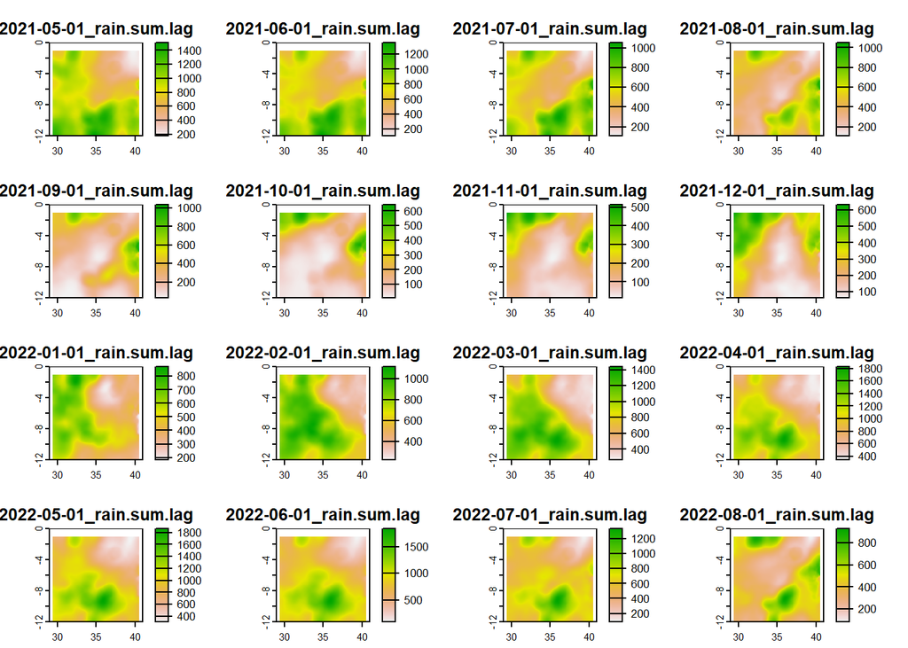

```r
names(lagged_rainfall_sum_filtered) <- paste0(names(lagged_rainfall_sum_filtered), "_rain.sum.lag")

plot(lagged_rainfall_sum_filtered)
```

```r
## We'll have to include lagged_rainfall_sum_filtered in the predictor stack.
rstack
```

```
## class       : SpatRaster
## dimensions  : 144, 144, 26  (nrow, ncol, nlyr)
## resolution  : 0.08333333, 0.08333333  (x, y)
## extent      : 29, 41, -12, 0  (xmin, xmax, ymin, ymax)
## coord. ref. : lon/lat WGS 84 (EPSG:4326)
## source(s)   : memory
## names       :    ttcity_u5,  ttport_1,     bio_1,     bio_2,    bio_3,     bio_4, ...
## min values  : 3.350081e-02,  997.9427,  4.333545,  6.546645, 53.85881,  19.75255, ...
## max values  : 1.166560e+03, 3043.3459, 28.472235, 15.285786, 93.14099, 266.33594, ...
```

```r
names(rstack)
```

```
##  [1] "ttcity_u5" "ttport_1"  "bio_1"     "bio_2"     "bio_3"     "bio_4"
##  [7] "bio_5"     "bio_6"     "bio_7"     "bio_8"     "bio_9"     "bio_10"
## [13] "bio_11"    "bio_12"    "bio_13"    "bio_14"    "bio_15"    "bio_16"
## [19] "bio_17"    "bio_18"    "bio_19"    "MAI_ARE"   "MAI_YLD"   "popdens"
## [25] "latitude"  "longitude"
```

```r
rstack3 <- c(rstack, lagged_rainfall_sum_filtered)
names(rstack3)
```

```
##  [1] "ttcity_u5"               "ttport_1"
##  [3] "bio_1"                   "bio_2"
##  [5] "bio_3"                   "bio_4"
##  [7] "bio_5"                   "bio_6"
##  [9] "bio_7"                   "bio_8"
## [11] "bio_9"                   "bio_10"
## [13] "bio_11"                  "bio_12"
## [15] "bio_13"                  "bio_14"
## [17] "bio_15"                  "bio_16"
## [19] "bio_17"                  "bio_18"
## [21] "bio_19"                  "MAI_ARE"
## [23] "MAI_YLD"                 "popdens"
## [25] "latitude"                "longitude"
## [27] "2021-05-01_rain.sum.lag" "2021-06-01_rain.sum.lag"
## [29] "2021-07-01_rain.sum.lag" "2021-08-01_rain.sum.lag"
```

[output cut: 18 more lines]

```r
#Extract to the point dataset
extr1 <- terra::extract(rstack3, mypts, method = "bilinear")
mypts <- cbind(mypts, extr1)
# Remove the ID column from the dataset
mypts <- mypts[, !names(mypts) %in% "ID"]
head(mypts)
```

```
##          Region   Market Month Year Latitude Longitude  Crop    pkg maize rice
## 1        Arusha   Arusha     5 2021 -3.36968  36.68808 Maize 469.00     1    0
## 2 Dar es Salaam   Temeke     5 2021 -6.85097  39.25672 Maize 485.00     1    0
## 3        Dodoma  Majengo     5 2021 -6.17971  35.74109 Maize 501.50     1    0
## 4        Dodoma Kibaigwa     5 2021 -6.08110  36.64645 Maize 375.00     1    0
## 5        Kagera   Bukoba     5 2021 -1.33140  31.81293 Maize 426.25     1    0
## 6       Manyara   Babati     5 2021 -4.21006  35.74915 Maize 375.00     1    0
##   sorghum bmillet fmillet wheat beans potato jan feb mar apr may jun jul aug
## 1       0       0       0     0     0      0   0   0   0   0   1   0   0   0
## 2       0       0       0     0     0      0   0   0   0   0   1   0   0   0
## 3       0       0       0     0     0      0   0   0   0   0   1   0   0   0
## 4       0       0       0     0     0      0   0   0   0   0   1   0   0   0
## 5       0       0       0     0     0      0   0   0   0   0   1   0   0   0
## 6       0       0       0     0     0      0   0   0   0   0   1   0   0   0
##   sep oct nov dec   ttcity_u5 ttport_1    bio_1     bio_2    bio_3     bio_4
```

[output cut: 118 more lines]

Here we extract sum of lag rainfall for each row under the column rain.sum.lag

```r
mypts_df <- as.data.frame(mypts)

# Define the function to obtain sum of lag rainfall from corresponding rasters to mypts under rain.sum.lag column (for each row)
# Each extraction has to match the month and year
get_rain_sum_row <- function(current_date, mypts_row) {
  # Extract the rainfall value for the current date
  rain_sum <- mypts_row[[paste0(current_date, "_rain.sum.lag")]]
  return(rain_sum)
}

# Loop through each row and obtain the rainfall sum for each month and year
for (i in 1:nrow(mypts_df)) {
  # Extract relevant data for the current row
  month <- mypts_df$Month[i]
  year <- mypts_df$Year[i]
  current_date <- paste0(year, "-", sprintf("%02d", month), "-01")  # Format date correctly
  # Pass necessary data to the function
  rain_sum <- get_rain_sum_row(current_date, mypts_df[i, ])
  # Update the rain.sum.lag column
  mypts_df$rain.sum.lag[i] <- rain_sum
}

# Update the SpatVector with the new rain.avg column
mypts$rain.sum.lag <- mypts_df$rain.sum.lag
```

```r
# I'll drop the dates with rain.sum.lag from mypts, seems redundant
column_indices <- grep("^202[0-4]-", names(mypts))
mypts <- mypts[, -column_indices]
names(mypts)
```

```
##  [1] "Region"       "Market"       "Month"        "Year"         "Latitude"
##  [6] "Longitude"    "Crop"         "pkg"          "maize"        "rice"
## [11] "sorghum"      "bmillet"      "fmillet"      "wheat"        "beans"
## [16] "potato"       "jan"          "feb"          "mar"          "apr"
## [21] "may"          "jun"          "jul"          "aug"          "sep"
## [26] "oct"          "nov"          "dec"          "ttcity_u5"    "ttport_1"
## [31] "bio_1"        "bio_2"        "bio_3"        "bio_4"        "bio_5"
## [36] "bio_6"        "bio_7"        "bio_8"        "bio_9"        "bio_10"
## [41] "bio_11"       "bio_12"       "bio_13"       "bio_14"       "bio_15"
## [46] "bio_16"       "bio_17"       "bio_18"       "bio_19"       "MAI_ARE"
## [51] "MAI_YLD"      "popdens"      "latitude"     "longitude"    "rain.sum.lag"
```

```r
#define Month as a factor
#mypts$Month <- as.factor(mypts$Month)
#levels(mypts$Month)

#We'll define month as an interger instead.
# Check to make sure Month is interger
sapply(mypts, class)
```

```
##       Region       Market        Month         Year     Latitude    Longitude
##  "character"  "character"    "integer"    "integer"    "numeric"    "numeric"
##         Crop          pkg        maize         rice      sorghum      bmillet
##     "factor"    "numeric"    "numeric"    "numeric"    "numeric"    "numeric"
##      fmillet        wheat        beans       potato          jan          feb
##    "numeric"    "numeric"    "numeric"    "numeric"    "numeric"    "numeric"
##          mar          apr          may          jun          jul          aug
##    "numeric"    "numeric"    "numeric"    "numeric"    "numeric"    "numeric"
##          sep          oct          nov          dec    ttcity_u5     ttport_1
##    "numeric"    "numeric"    "numeric"    "numeric"    "numeric"    "numeric"
##        bio_1        bio_2        bio_3        bio_4        bio_5        bio_6
##    "numeric"    "numeric"    "numeric"    "numeric"    "numeric"    "numeric"
##        bio_7        bio_8        bio_9       bio_10       bio_11       bio_12
##    "numeric"    "numeric"    "numeric"    "numeric"    "numeric"    "numeric"
##       bio_13       bio_14       bio_15       bio_16       bio_17       bio_18
##    "numeric"    "numeric"    "numeric"    "numeric"    "numeric"    "numeric"
##       bio_19      MAI_ARE      MAI_YLD      popdens     latitude    longitude
##    "numeric"    "numeric"    "numeric"    "numeric"    "numeric"    "numeric"
## rain.sum.lag
##    "numeric"
```

```r
# drop levels that don't exist in Crop field
mypts$Crop <- mypts$Crop[,drop=TRUE]
levels(mypts$Crop)
```

```
## [1] "Maize"    "Rice"     "Sorghum"  "B.Millet" "F.Millet" "Wheat"    "Beans"
## [8] "Potato"
```

# Linear model price Prediction

Coefficient estimates from the linear model provide a detailed insight into the relationship between each predictor and the response variable.

```r
# Fit the linear model
lm_model <- lm(pkg ~ maize + rice + sorghum + bmillet + fmillet + wheat + beans + potato +
                 Month +
                 Year +
                 ttcity_u5 + ttport_1 +
                 bio_1 + bio_2 + bio_3 + bio_4 + bio_5 + bio_6 +
                 bio_7 + bio_8 + bio_9 + bio_10 + bio_11 + bio_12 + bio_13 + bio_14                  + bio_15 + bio_16 + bio_17 + bio_18 + bio_19 +
                 MAI_ARE + MAI_YLD +
                 Longitude + Latitude +
                 rain.sum.lag,
               data = mypts)

summary(lm_model)
```

```
##
## Call:
## lm(formula = pkg ~ maize + rice + sorghum + bmillet + fmillet +
##     wheat + beans + potato + Month + Year + ttcity_u5 + ttport_1 +
##     bio_1 + bio_2 + bio_3 + bio_4 + bio_5 + bio_6 + bio_7 + bio_8 +
##     bio_9 + bio_10 + bio_11 + bio_12 + bio_13 + bio_14 + bio_15 +
##     bio_16 + bio_17 + bio_18 + bio_19 + MAI_ARE + MAI_YLD + Longitude +
##     Latitude + rain.sum.lag, data = mypts)
##
## Residuals:
##      Min       1Q   Median       3Q      Max
## -1459.51  -243.70   -13.83   238.66  1620.17
##
## Coefficients: (2 not defined because of singularities)
##                Estimate Std. Error t value Pr(>|t|)
## (Intercept)  -4.233e+05  1.191e+04 -35.529  < 2e-16 ***
## maize        -6.523e+01  1.844e+01  -3.537 0.000408 ***
## rice          1.381e+03  1.844e+01  74.904  < 2e-16 ***
## sorghum       3.849e+02  1.950e+01  19.743  < 2e-16 ***
## bmillet       4.723e+02  2.091e+01  22.580  < 2e-16 ***
## fmillet       7.840e+02  1.925e+01  40.735  < 2e-16 ***
## wheat         9.450e+02  2.114e+01  44.707  < 2e-16 ***
## beans         1.518e+03  1.846e+01  82.214  < 2e-16 ***
## potato               NA         NA      NA       NA
## Month         4.276e+00  1.898e+00   2.253 0.024292 *
## Year          2.013e+02  5.651e+00  35.622  < 2e-16 ***
## ttcity_u5     1.860e+00  1.595e-01  11.661  < 2e-16 ***
## ttport_1     -1.884e+00  1.697e-01 -11.103  < 2e-16 ***
## bio_1        -2.381e+03  1.913e+02 -12.445  < 2e-16 ***
## bio_2        -2.564e+03  2.390e+02 -10.726  < 2e-16 ***
## bio_3         2.211e+02  1.924e+01  11.493  < 2e-16 ***
## bio_4         2.042e+01  4.048e+00   5.046 4.65e-07 ***
## bio_5         1.899e+03  1.843e+02  10.305  < 2e-16 ***
## bio_6        -1.860e+03  1.952e+02  -9.527  < 2e-16 ***
## bio_7                NA         NA      NA       NA
## bio_8         8.773e+02  9.767e+01   8.982  < 2e-16 ***
## bio_9        -4.409e+01  8.071e+01  -0.546 0.584883
## bio_10       -1.086e+03  2.162e+02  -5.024 5.21e-07 ***
## bio_11        2.628e+03  3.105e+02   8.465  < 2e-16 ***
## bio_12        1.087e+00  2.744e-01   3.963 7.50e-05 ***
## bio_13        2.895e-01  9.237e-01   0.313 0.753959
## bio_14        5.356e+01  1.231e+01   4.352 1.37e-05 ***
## bio_15        2.023e+01  2.103e+00   9.620  < 2e-16 ***
## bio_16       -1.176e+00  7.576e-01  -1.553 0.120493
## bio_17       -1.533e+01  3.553e+00  -4.315 1.62e-05 ***
## bio_18        1.488e-01  2.500e-01   0.595 0.551679
## bio_19        3.072e+00  2.777e+00   1.106 0.268608
## MAI_ARE      -1.173e-02  3.274e-02  -0.358 0.720176
## MAI_YLD       1.315e-01  1.745e-02   7.537 5.54e-14 ***
## Longitude     7.918e+01  3.568e+01   2.219 0.026521 *
## Latitude      9.897e-01  3.509e+01   0.028 0.977500
## rain.sum.lag -2.107e-01  1.945e-02 -10.835  < 2e-16 ***
## ---
## Signif. codes:  0 '***' 0.001 '**' 0.01 '*' 0.05 '.' 0.1 ' ' 1
##
## Residual standard error: 379 on 5898 degrees of freedom
## Multiple R-squared:  0.7341, Adjusted R-squared:  0.7325
## F-statistic: 478.9 on 34 and 5898 DF,  p-value: < 2.2e-16
```

# RandomForest and TPS

## Random Forest price prediction

First check if there are any predictors with NA values

```r
for(column in seq_along(mypts)){
  if(any(is.na(mypts[column]))){
    print(paste0("Column: ", colnames(mypts)[column], " has at least one NA value"))
  }
}

#There are no columns with missing values
```

## Split data the to be used for Training and validation

```r
# Filter the data for training (May 2021 - Dec 2023)
training_data <- mypts[mypts$Year %in% c(2021, 2022, 2023), ]
# Check training data
#head(training_data)
```

```r
# Filter the data for validation (Jan 2024 - June 2024)
validation_data <- mypts[mypts$Year == 2024, ]
# Check validation data
#head(validation_data)
```

### Random Forest for generating variable of importance

### Tune The Forest

The tuneRF function in the randomForest package is used to tune the mtry parameter, which is the number of variables randomly sampled as candidates at each split in the random forest. The function requires a data frame of predictor variables and a response variable.

```r
# Convert training_data data to data frame
mypts_df <- as.data.frame(training_data)

trf <- tuneRF(x=mypts_df[,1:ncol(mypts_df)], # Prediction variables
              y=mypts_df$pkg) # Response variable
```

```
## mtry = 18  OOB error = 1350.818
## Searching left ...
## mtry = 9     OOB error = 7006.815
## -4.187091 0.05
## Searching right ...
## mtry = 36    OOB error = 155.8048
## 0.8846589 0.05
## mtry = 55    OOB error = 91.25705
## 0.414286 0.05
```

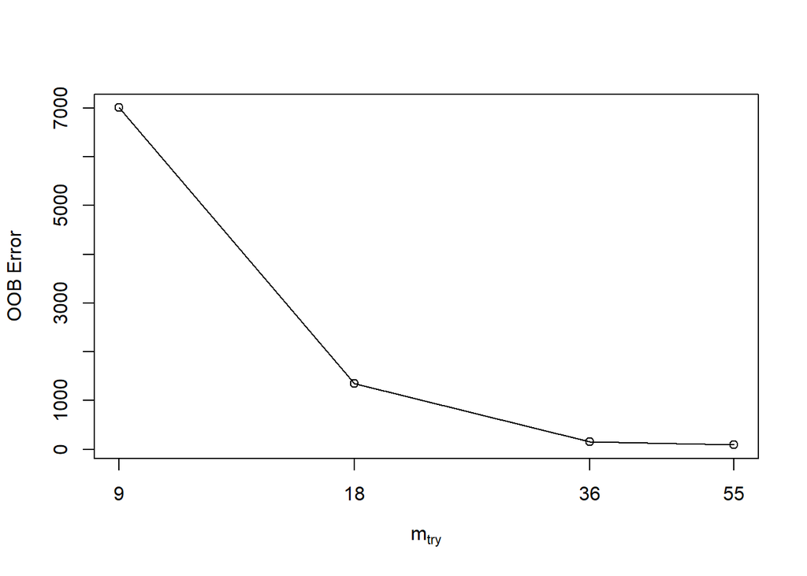

Based on the output from tuneRF, you can observe that the mtry value that gives the lowest Out-of-Bag (OOB) error. To build the first random forest model, we will use this mtry value.

```r
(mintree <- trf[which.min(trf[,2]),1])
```

```
## [1] 55
```

### Fit The Random Forest Model (1)

#### Random Forest for generating variable of importance

Here, the model is fitted using the randomForest function to build a predictive model for food commodity prices. The model takes the response variable, the prediction variables and the optimal number of variables to consider at each split. The goal is to generate Variable importance scores which will help us understand which variables have the most significant impact on the response variable, enabling us to interpret the model and possibly simplify it by focusing on the most important predictors.

```r
# Create the random forest model
rf1 <- randomForest(pkg ~ maize + rice + sorghum + bmillet + fmillet + wheat + beans + potato +
                      Month +
                      Year +
                      ttcity_u5 + ttport_1 +
                      bio_1 + bio_2 + bio_3 + bio_4 + bio_5 + bio_6 +
                      bio_7 + bio_8 + bio_9 + bio_10 + bio_11 + bio_12 + bio_13 +                        bio_14 + bio_15 + bio_16 + bio_17 + bio_18 + bio_19 +
                      MAI_ARE + MAI_YLD +
                      Longitude + Latitude +
                      rain.sum.lag,
                    data = training_data,mtry=mintree,importance=TRUE,na.rm=TRUE)
rf1
```

```
##
## Call:
##  randomForest(formula = pkg ~ maize + rice + sorghum + bmillet +      fmillet + wheat + beans + potato + Month + Year + ttcity_u5 +      ttport_1 + bio_1 + bio_2 + bio_3 + bio_4 + bio_5 + bio_6 +      bio_7 + bio_8 + bio_9 + bio_10 + bio_11 + bio_12 + bio_13 +      bio_14 + bio_15 + bio_16 + bio_…
##                Type of random forest: regression
##                      Number of trees: 500
## No. of variables tried at each split: 36
##
##           Mean of squared residuals: 23992.53
##                     % Var explained: 95.4
```

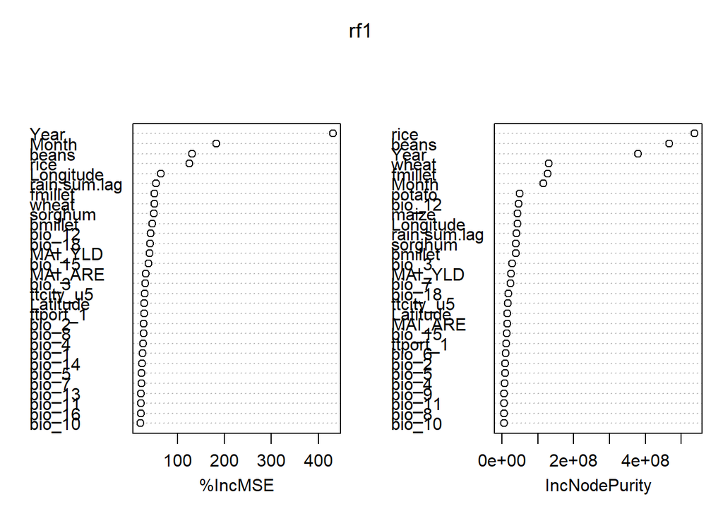

```r
varImpPlot(rf1)
```

```r
## evaluate
(oob <- sqrt(rf1$mse[which.min(rf1$mse)]))
```

```
## [1] 154.7101
```

This calculates the RMSE of the tree in the Random Forest model that has the lowest OOB error.

```r
importance_metrics <- importance(rf1, type=1)  # %IncMSE
impvar <- rownames(importance_metrics)[order(importance_metrics[, 1], decreasing=TRUE)]
impvar
```

```
##  [1] "Year"         "Month"        "beans"        "rice"         "Longitude"
##  [6] "rain.sum.lag" "fmillet"      "wheat"        "sorghum"      "bmillet"
## [11] "bio_12"       "bio_18"       "MAI_YLD"      "bio_15"       "MAI_ARE"
## [16] "bio_3"        "ttcity_u5"    "Latitude"     "ttport_1"     "bio_2"
## [21] "bio_8"        "bio_4"        "bio_1"        "bio_14"       "bio_5"
## [26] "bio_7"        "bio_13"       "bio_11"       "bio_16"       "bio_10"
## [31] "bio_6"        "bio_19"       "maize"        "bio_9"        "potato"
## [36] "bio_17"
```

```r
# Get the top 20 variables
top_20_vars <- impvar[1:20]
top_20_vars
```

```
##  [1] "Year"         "Month"        "beans"        "rice"         "Longitude"
##  [6] "rain.sum.lag" "fmillet"      "wheat"        "sorghum"      "bmillet"
## [11] "bio_12"       "bio_18"       "MAI_YLD"      "bio_15"       "MAI_ARE"
## [16] "bio_3"        "ttcity_u5"    "Latitude"     "ttport_1"     "bio_2"
```

```r
node_purity <- importance(rf1, type=2)  # IncNodePurity
# Sort variables by importance (IncNodePurity)
node_purity_sorted <- sort(node_purity[,1], decreasing = TRUE)
node_purity_sorted
```

```
##         rice        beans         Year        wheat      fmillet        Month
##    537127817    466842514    380388805    131058156    127560634    114732842
##       potato       bio_12        maize    Longitude rain.sum.lag      sorghum
##     49729419     45951002     43414090     43009140     40344444     39020394
##      bmillet        bio_3      MAI_YLD        bio_7       bio_18    ttcity_u5
##     38185514     27679081     24717292     23928361     17424075     15991756
##     Latitude      MAI_ARE       bio_15     ttport_1        bio_6        bio_2
##     14238819     14126778     13630288     12292185      9976545      8630842
##        bio_5        bio_4        bio_9       bio_11        bio_8       bio_10
##      7958109      7043691      6035166      5531405      5380741      5294050
##       bio_19        bio_1       bio_13       bio_16       bio_14       bio_17
##      5012073      4953527      4828056      4591865      4321322      2834622
```

```r
# Select the top 20 important variables
top_vars <- names(node_purity_sorted)[1:20]
print(top_vars)
```

```
##  [1] "rice"         "beans"        "Year"         "wheat"        "fmillet"
##  [6] "Month"        "potato"       "bio_12"       "maize"        "Longitude"
## [11] "rain.sum.lag" "sorghum"      "bmillet"      "bio_3"        "MAI_YLD"
## [16] "bio_7"        "bio_18"       "ttcity_u5"    "Latitude"     "MAI_ARE"
```

```r
rf1$importanceSD
```

```
##        maize         rice      sorghum      bmillet      fmillet        wheat
##   1983.76869   2901.76550    571.18768    667.06925   1675.09637   1611.60029
##        beans       potato        Month         Year    ttcity_u5     ttport_1
##   3025.10953   2056.80364    275.24757    507.18487    260.09925    234.27023
##        bio_1        bio_2        bio_3        bio_4        bio_5        bio_6
##    120.24193    228.55221    590.50143    172.02651    196.30755    305.19412
##        bio_7        bio_8        bio_9       bio_10       bio_11       bio_12
##    715.78164    116.03203    290.06653    150.57802    140.41312    823.67181
##       bio_13       bio_14       bio_15       bio_16       bio_17       bio_18
##    140.32204     99.90244    259.77001    126.00875    136.64634    274.63460
##       bio_19      MAI_ARE      MAI_YLD    Longitude     Latitude rain.sum.lag
##    192.57925    259.25070    421.06640    357.49980    337.54338    172.75824
```

### Fit The Random Forest Model (2)

#### Estimate more parsimonious specification

```r
# Estimate more parsimonious specification
rf <- randomForest(pkg ~ maize + rice + sorghum + bmillet + fmillet + wheat + beans + potato +
                     Month +
                     Year +
                     ttport_1 +
                     bio_3 + bio_6  + bio_9 + bio_12 +
                     rain.sum.lag,
                   data=training_data, na.rm=TRUE)

rf
```

```
##
## Call:
##  randomForest(formula = pkg ~ maize + rice + sorghum + bmillet +      fmillet + wheat + beans + potato + Month + Year + ttport_1 +      bio_3 + bio_6 + bio_9 + bio_12 + rain.sum.lag, data = training_data,      na.rm = TRUE)
##                Type of random forest: regression
##                      Number of trees: 500
## No. of variables tried at each split: 5
##
##           Mean of squared residuals: 30081.9
##                     % Var explained: 94.23
```

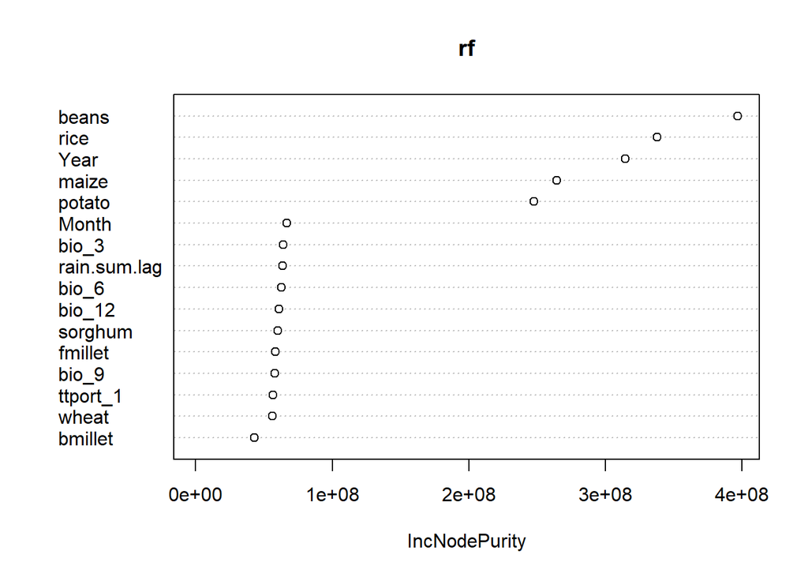

```r
# evaluate
varImpPlot(rf)
```

```r
(oob <- sqrt(rf$mse[which.min(rf$mse)]))
```

```
## [1] 172.4226
```

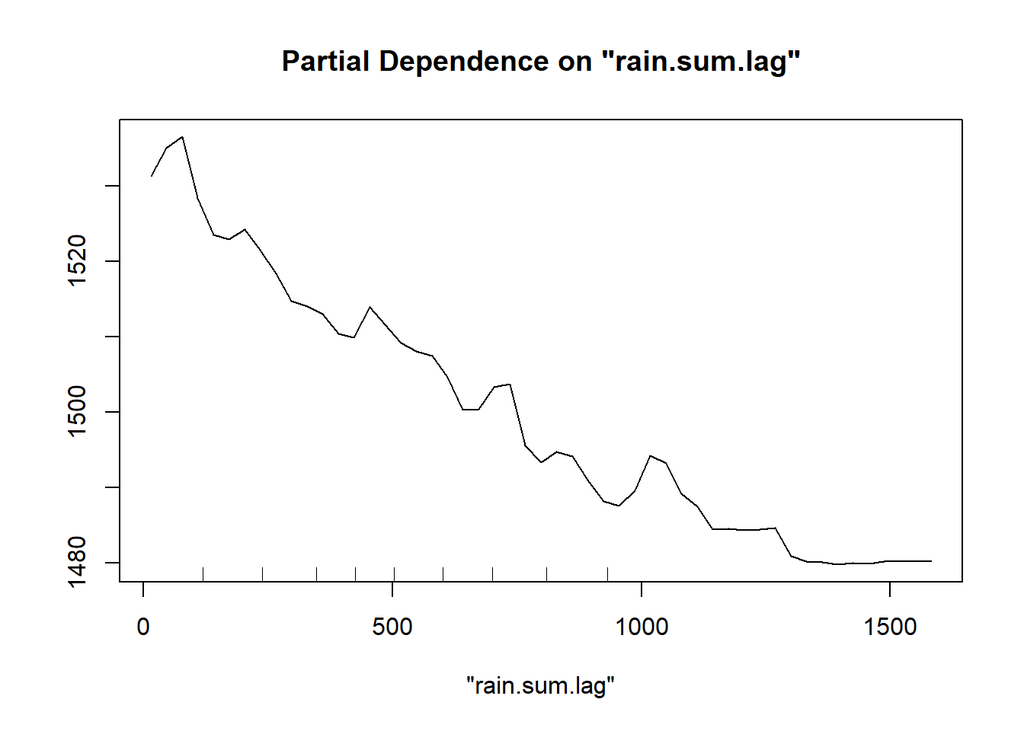

```r
partialPlot(rf, as.data.frame(training_data), "rain.sum.lag")
```

## spatial prediction

These are prediction plots for each food commodities (maize, beans, rice, sorghum, bmillet, fmillet, wheat, potato) with their respective month of the year 2023.

```r
year <- 2023
```

Note: we must set the rain.sum.lag variables for each month we are predicting

### Predicted Maize Prices

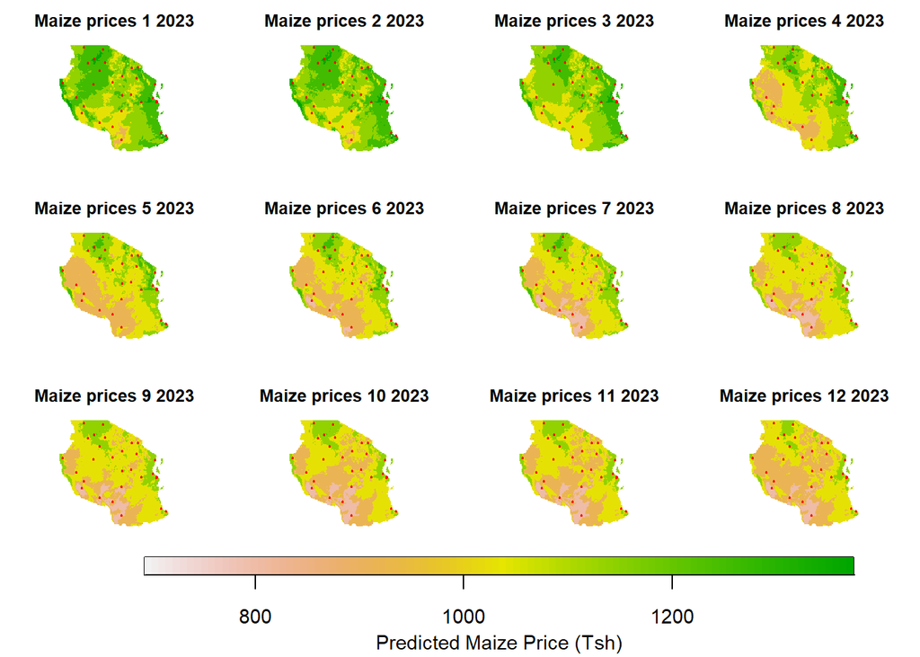

```r
#Maize
# Create an empty list to store predictions for maize
predict_for_month <- function(month){
  rain_sum_lag <- rstack3[paste0("2023-", sprintf("%02d", month), "-01_rain.sum.lag")] # Remember to change depending on year
  names(rain_sum_lag) <- "rain.sum.lag"

  newstack <- c(rstack, rain_sum_lag)

  const_maize <- data.frame(
    maize = 1, rice = 0, sorghum = 0, bmillet = 0, fmillet = 0, wheat = 0, beans = 0, potato = 0,
    Month = month,
    Year = year
  )

  pred <- predict(newstack, rf, const = const_maize, na.rm = TRUE)
  pred <- mask(pred, tza1)
  return(pred)
}

# Create predictions for all months
predictions_maize <- lapply(1:12, predict_for_month)


# Extract pixel values from predictions_maize
maize_values <- unlist(lapply(predictions_maize, values))
# Get min and max values
min_maize <- min(maize_values, na.rm = TRUE)
max_maize <- max(maize_values, na.rm = TRUE)

# Define the continuous color palette and reverse it
color_palette <- rev(terrain.colors(100))

# Set up plot layout with an extra row for the legend
layout_matrix <- matrix(c(1, 2, 3, 4,
                          5, 6, 7, 8,
                          9, 10, 11, 12,
                          13, 13, 13, 13), nrow = 4, byrow = TRUE)

# Set up layout
layout(layout_matrix, heights = c(1, 1, 1, 0.5))

break_interval <- 100

# Set up plot layout with an extra row for the legend
layout_matrix <- matrix(c(1, 2, 3, 4,
                          5, 6, 7, 8,
                          9, 10, 11, 12,
                          13, 13, 13, 13), nrow = 4, byrow = TRUE)

# Set up layout
layout(layout_matrix, heights = c(1, 1, 1, 0.5))

break_interval <- 100

# Create a 3x4 matrix of plots
par(mar = c(0, 0, 0, 0))  # Set margins to 0 for inner plots
for (i in 1:12) {
  plot(predictions_maize[[i]], main = paste("Maize prices", toupper(i), year),
       zlim = c(min_maize, max_maize), col = color_palette, breaks = seq(min_maize, max_maize, by = break_interval), legend = FALSE, axes = FALSE)
  points(training_data, pch = 20, col = "red", cex = 0.5)
}

# Generate pretty breaks for the legend
legend_breaks <- pretty(c(min_maize, max_maize), n = 4)

# Reset plot layout for the legend
layout(matrix(1))
par(mar = c(5, 4, 2, 1))

# Plot the legend in the bottom row, centered horizontally
image.plot(zlim = c(min_maize, max_maize), legend.only = TRUE,
           col = color_palette, horizontal = TRUE,
           legend.width = 0.7, legend.shrink = 0.9,
           axis.args = list(at = legend_breaks, labels = legend_breaks, cex.axis = 0.9),
           legend.args = list(text = "Predicted Maize Price (Tsh)", side = 1, line = 2, cex = 0.9))
```

### Predicted Beans Prices

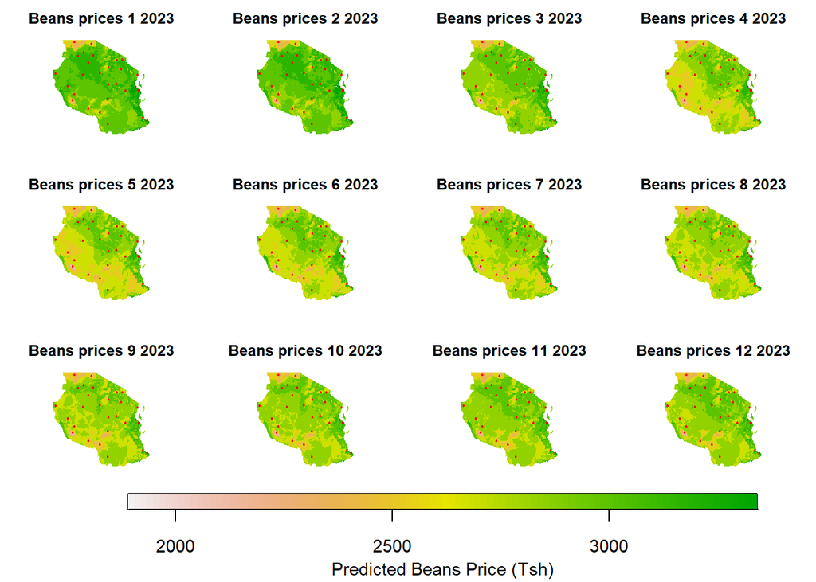

```r
# Beans
# Function to predict beans for a given month
predict_for_beans <- function(month) {
  rain_sum_lag <- rstack3[paste0("2023-", sprintf("%02d", month), "-01_rain.sum.lag")]
  names(rain_sum_lag) <- "rain.sum.lag"

  newstack <- c(rstack, rain_sum_lag)

  const_beans <- data.frame(
    maize = 0, rice = 0, sorghum = 0, bmillet = 0, fmillet = 0, wheat = 0, beans = 1, potato = 0,
    Month = month,
    Year = year
  )

  pred <- predict(newstack, rf, const = const_beans, na.rm = TRUE)
  pred <- mask(pred, tza1)
  return(pred)
}

# Create predictions for all months
predictions_beans <- lapply(1:12, predict_for_beans)

# Extract pixel values from predictions_beans
bean_values <- unlist(lapply(predictions_beans, values))
min_bean <- min(bean_values, na.rm = TRUE)
max_bean <- max(bean_values, na.rm = TRUE)

# Define the continuous color palette and reverse it
color_palette <- rev(terrain.colors(100))

# Set up plot layout with an extra row for the legend
layout_matrix <- matrix(c(1, 2, 3, 4,
                          5, 6, 7, 8,
                          9, 10, 11, 12,
                          13, 13, 13, 13), nrow = 4, byrow = TRUE)

# Set up layout
layout(layout_matrix, heights = c(1, 1, 1, 0.5))

break_interval <- 150

# Loop through each month to plot beans prices
par(mar = c(0, 0, 0, 0))
for (i in 1:12) {
  plot(predictions_beans[[i]], main = paste("Beans prices", toupper(i), year),
       zlim = c(min_bean, max_bean), col = color_palette, breaks = seq(min_bean, max_bean, by = break_interval), legend = FALSE, axes = FALSE)
  points(training_data, pch = 20, col = "red", cex = 0.5)
}

# Generate pretty breaks for the legend
legend_breaks <- pretty(c(min_bean, max_bean), n = 4)

# Reset plot layout to 1x1 for the legend
layout(matrix(1))

# Set margins for the legend
par(mar = c(5, 4, 2, 1))

# Plot the legend in the bottom row, centered horizontally
image.plot(zlim = c(min_bean, max_bean), legend.only = TRUE,
           col = color_palette, horizontal = TRUE,
           legend.width = 0.7, legend.shrink = 0.9,
           axis.args = list(at = legend_breaks, labels = legend_breaks, cex.axis = 0.9),
           legend.args = list(text = "Predicted Beans Price (Tsh)", side = 1, line = 2, cex = 0.9))
```

### Predicted Rice Prices

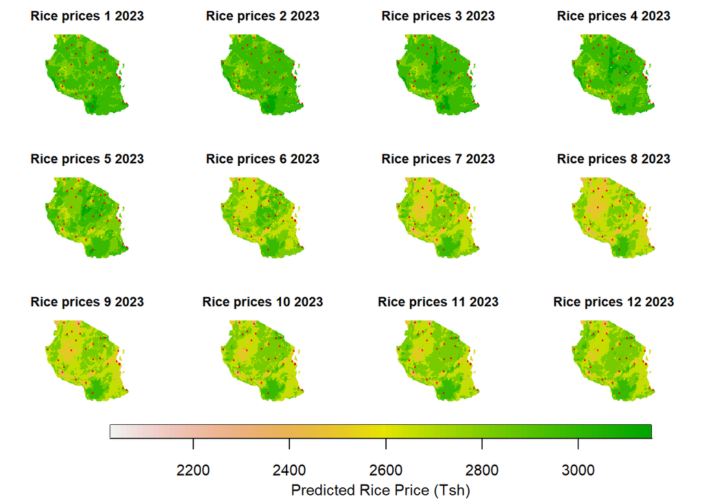

```r
# Rice
# Function to predict rice prices for a given month
predict_for_rice <- function(month) {
  rain_sum_lag <- rstack3[paste0("2023-", sprintf("%02d", month), "-01_rain.sum.lag")]
  names(rain_sum_lag) <- "rain.sum.lag"

  newstack <- c(rstack, rain_sum_lag)

  const_rice <- data.frame(
    maize = 0, rice = 1, sorghum = 0, bmillet = 0, fmillet = 0, wheat = 0, beans = 0, potato = 0,
    Month = month,
    Year = year
  )

  pred <- predict(newstack, rf, const = const_rice, na.rm = TRUE)
  pred <- mask(pred, tza1)
  return(pred)
}

# Create predictions for all months
predictions_rice <- lapply(1:12, predict_for_rice)

# Extract pixel values from predictions_rice
rice_values <- unlist(lapply(predictions_rice, values))
min_rice <- min(rice_values, na.rm = TRUE)
max_rice <- max(rice_values, na.rm = TRUE)

# Define the continuous color palette and reverse it
color_palette <- rev(terrain.colors(100))

# Set up plot layout with an extra row for the legend
layout_matrix <- matrix(c(1, 2, 3, 4,
                          5, 6, 7, 8,
                          9, 10, 11, 12,
                          13, 13, 13, 13), nrow = 4, byrow = TRUE)

# Set up layout
layout(layout_matrix, heights = c(1, 1, 1, 0.5))

break_interval <- 150

# Loop through each month to plot rice prices
par(mar = c(0, 0, 0, 0))
for (i in 1:12) {
  plot(predictions_rice[[i]], main = paste("Rice prices", toupper(i), year),
       zlim = c(min_rice, max_rice), col = color_palette, breaks = seq(min_rice, max_rice, by = break_interval), legend = FALSE, axes = FALSE)
  points(training_data, pch = 20, col = "red", cex = 0.5)
}

# Generate pretty breaks for the legend
legend_breaks <- pretty(c(min_rice, max_rice), n = 5)

# Reset plot layout to 1x1 for the legend
layout(matrix(1))

# Set margins for the legend
par(mar = c(5, 4, 2, 1))

# Plot the legend in the bottom row, centered horizontally
image.plot(zlim = c(min_rice, max_rice), legend.only = TRUE,
           col = color_palette, horizontal = TRUE,
           legend.width = 0.7, legend.shrink = 0.9,
           axis.args = list(at = legend_breaks, labels = legend_breaks, cex.axis = 0.9),
           legend.args = list(text = "Predicted Rice Price (Tsh)", side = 1, line = 2, cex = 0.9))
```

### Predicted Sorghum Prices

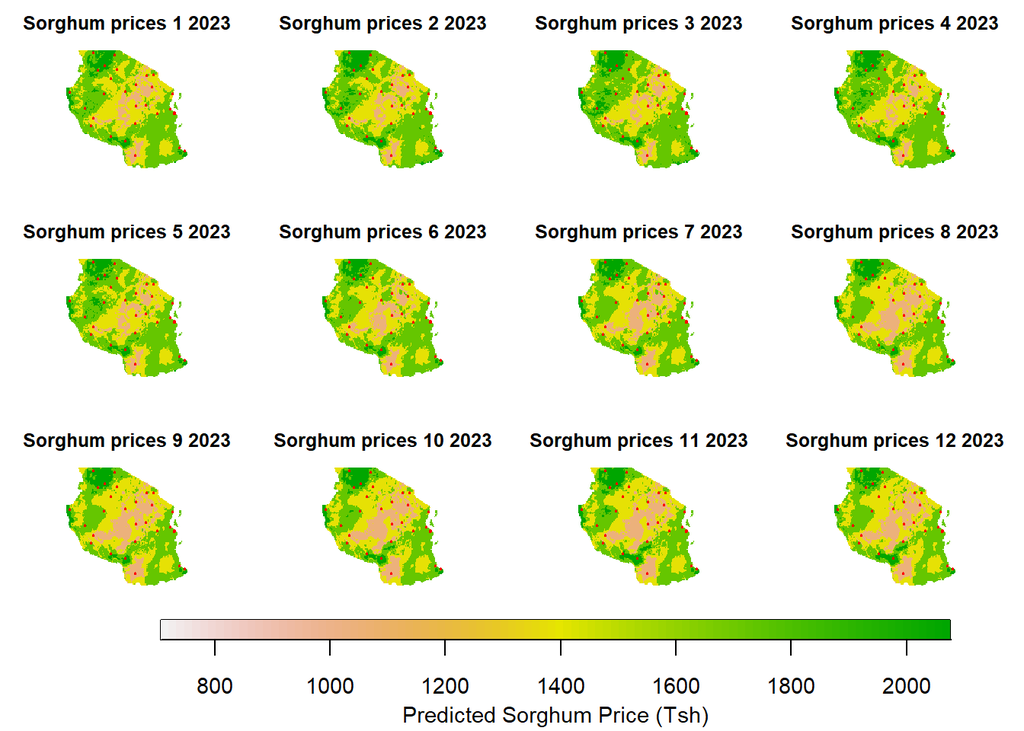

```r
# Function to predict sorghum prices for a given month
predict_for_sorghum <- function(month) {
  rain_sum_lag <- rstack3[paste0("2023-", sprintf("%02d", month), "-01_rain.sum.lag")]
  names(rain_sum_lag) <- "rain.sum.lag"

  newstack <- c(rstack, rain_sum_lag)

  const_sorghum <- data.frame(
    maize = 0, rice = 0, sorghum = 1, bmillet = 0, fmillet = 0, wheat = 0, beans = 0, potato = 0,
    Month = month,
    Year = 2023
  )

  pred <- predict(newstack, rf, const = const_sorghum, na.rm = TRUE)
  pred <- mask(pred, tza1)
  return(pred)
}

# Create predictions for all months
predictions_sorghum <- lapply(1:12, predict_for_sorghum)

# Extract pixel values from predictions_sorghum
sorghum_values <- unlist(lapply(predictions_sorghum, values))
min_sorghum <- min(sorghum_values, na.rm = TRUE)
max_sorghum <- max(sorghum_values, na.rm = TRUE)

# Define the continuous color palette and reverse it
color_palette <- rev(terrain.colors(100))

# Set up plot layout with an extra row for the legend
layout_matrix <- matrix(c(1, 2, 3, 4,
                          5, 6, 7, 8,
                          9, 10, 11, 12,
                          13, 13, 13, 13), nrow = 4, byrow = TRUE)

# Set up layout
layout(layout_matrix, heights = c(1, 1, 1, 0.5))

break_interval <- 300

# Loop through each month to plot sorghum prices
par(mar = c(0, 0, 0, 0))
for (i in 1:12) {
  plot(predictions_sorghum[[i]], main = paste("Sorghum prices", toupper(i), year),
       zlim = c(min_sorghum, max_sorghum), col = color_palette, breaks = seq(min_sorghum, max_sorghum, by = break_interval), legend = FALSE, axes = FALSE)
  points(training_data, pch = 20, col = "red", cex = 0.5)
}

# Generate pretty breaks for the legend
legend_breaks <- pretty(c(min_sorghum, max_sorghum), n = 5)

# Reset plot layout to 1x1 for the legend
layout(matrix(1))

# Set margins for the legend
par(mar = c(5, 4, 2, 1))

# Plot the legend in the bottom row, centered horizontally
image.plot(zlim = c(min_sorghum, max_sorghum), legend.only = TRUE,
           col = color_palette, horizontal = TRUE,
           legend.width = 0.7, legend.shrink = 0.9,
           axis.args = list(at = legend_breaks, labels = legend_breaks, cex.axis = 0.9),
           legend.args = list(text = "Predicted Sorghum Price (Tsh)", side = 1, line = 2, cex = 0.9))
```

### Predicted Bulrush Millet Prices

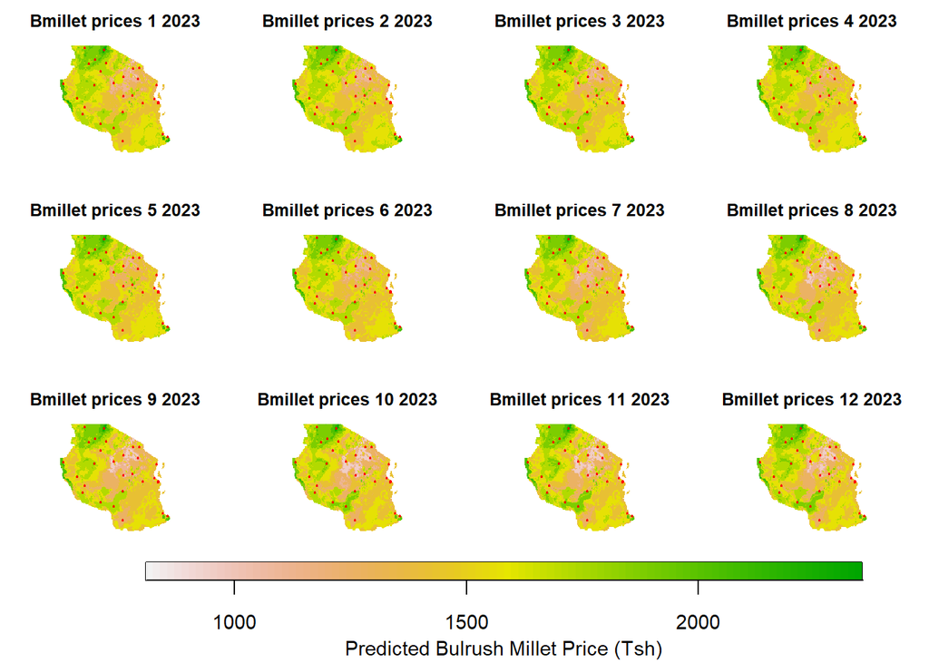

```r
# bmillet
# Function to predict bmillet prices for a given month
predict_for_bmillet <- function(month) {
  rain_sum_lag <- rstack3[paste0("2023-", sprintf("%02d", month), "-01_rain.sum.lag")]
  names(rain_sum_lag) <- "rain.sum.lag"

  newstack <- c(rstack, rain_sum_lag)

  const_bmillet <- data.frame(
    maize = 0, rice = 0, sorghum = 0, bmillet = 1, fmillet = 0, wheat = 0, beans = 0, potato = 0,
    Month = month,
    Year = year
  )

  pred <- predict(newstack, rf, const = const_bmillet, na.rm = TRUE)
  pred <- mask(pred, tza1)
  return(pred)
}

# Create predictions for all months
predictions_bmillet <- lapply(1:12, predict_for_bmillet)


# Extract pixel values from predictions_bmillet
bmillet_values <- unlist(lapply(predictions_bmillet, values))
min_bmillet <- min(bmillet_values, na.rm = TRUE)
max_bmillet <- max(bmillet_values, na.rm = TRUE)

# Define the continuous color palette and reverse it
color_palette <- rev(terrain.colors(100))

# Set up plot layout with an extra row for the legend
layout_matrix <- matrix(c(1, 2, 3, 4,
                          5, 6, 7, 8,
                          9, 10, 11, 12,
                          13, 13, 13, 13), nrow = 4, byrow = TRUE)

# Set up layout with an extra row for the legend
layout(layout_matrix, heights = c(1, 1, 1, 0.5))

# Loop through each month to plot bmillet prices
break_interval <- 150
par(mar = c(0, 0, 0, 0))
for (i in 1:12) {
  plot(predictions_bmillet[[i]], main = paste("Bmillet prices", toupper(i), year),
       zlim = c(min_bmillet, max_bmillet), col = color_palette,
       breaks = seq(min_bmillet, max_bmillet, by = break_interval),
       legend = FALSE, axes = FALSE)
  points(training_data, pch = 20, col = "red", cex = 0.5)
}

# Generate pretty breaks for the legend
legend_breaks <- pretty(c(min_bmillet, max_bmillet), n = 5)

# Reset plot layout to 1x1 for the legend
layout(matrix(1))

# Set margins for the legend
par(mar = c(5, 4, 2, 1))

# Plot the legend in the bottom row, centered horizontally
image.plot(zlim = c(min_bmillet, max_bmillet), legend.only = TRUE,
           col = color_palette, horizontal = TRUE,
           legend.width = 0.7, legend.shrink = 0.9,
           axis.args = list(at = legend_breaks, labels = legend_breaks, cex.axis = 0.9),
           legend.args = list(text = "Predicted Bulrush Millet Price (Tsh)", side = 1, line = 2, cex = 0.9))
```

### Predicted Finger Millet Prices

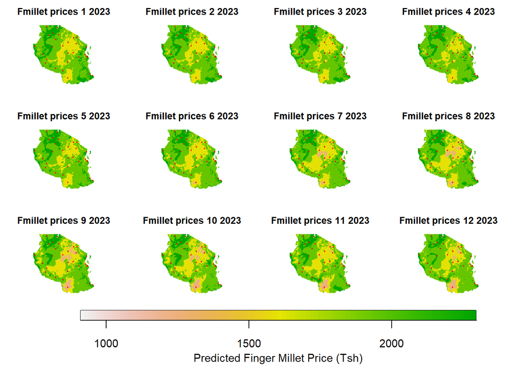

```r
#fmillet
# Function to predict fmillet prices for a given month
predict_for_fmillet <- function(month) {
  rain_sum_lag <- rstack3[paste0("2023-", sprintf("%02d", month), "-01_rain.sum.lag")]
  names(rain_sum_lag) <- "rain.sum.lag"

  newstack <- c(rstack, rain_sum_lag)

  const_fmillet <- data.frame(
    maize = 0, rice = 0, sorghum = 0, bmillet = 0, fmillet = 1, wheat = 0, beans = 0, potato = 0,
    Month = month,
    Year = year
  )

  pred <- predict(newstack, rf, const = const_fmillet, na.rm = TRUE)
  pred <- mask(pred, tza1)
  return(pred)
}

# Create predictions for all months
predictions_fmillet <- lapply(1:12, predict_for_fmillet)

# Extract pixel values from predictions_fmillet
fmillet_values <- unlist(lapply(predictions_fmillet, values))
min_fmillet <- min(fmillet_values, na.rm = TRUE)
max_fmillet <- max(fmillet_values, na.rm = TRUE)

# Define the continuous color palette and reverse it
color_palette <- rev(terrain.colors(100))

# Set up plot layout with an extra row for the legend
layout_matrix <- matrix(c(1, 2, 3, 4,
                          5, 6, 7, 8,
                          9, 10, 11, 12,
                          13, 13, 13, 13), nrow = 4, byrow = TRUE)

# Set up layout with an extra row for the legend
layout(layout_matrix, heights = c(1, 1, 1, 0.5))

# Loop through each month to plot fmillet prices
break_interval <- 300
par(mar = c(0, 0, 0, 0))
for (i in 1:12) {
  plot(predictions_fmillet[[i]], main = paste("Fmillet prices", toupper(i), year),
       zlim = c(min_fmillet, max_fmillet), col = color_palette,
       breaks = seq(min_fmillet, max_fmillet, by = break_interval),
       legend = FALSE, axes = FALSE)
  points(training_data, pch = 20, col = "red", cex = 0.5)
}

# Generate pretty breaks for the legend
legend_breaks <- pretty(c(min_fmillet, max_fmillet), n = 3)

# Reset plot layout to 1x1 for the legend
layout(matrix(1))

# Set margins for the legend
par(mar = c(5, 4, 2, 1))

# Plot the legend in the bottom row, centered horizontally
image.plot(zlim = c(min_fmillet, max_fmillet), legend.only = TRUE,
           col = color_palette, horizontal = TRUE,
           legend.width = 0.7, legend.shrink = 0.9,
           axis.args = list(at = legend_breaks, labels = legend_breaks, cex.axis = 0.9),
           legend.args = list(text = "Predicted Finger Millet Price (Tsh)", side = 1, line = 2, cex = 0.9))
```

### Predicted Wheat Prices

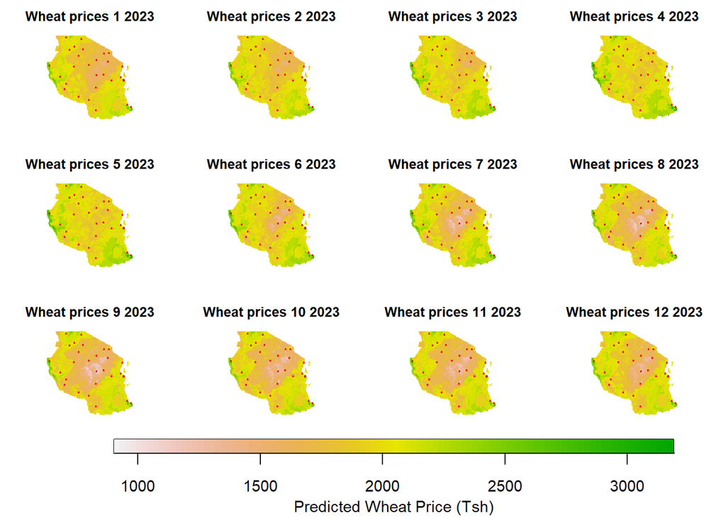

```r
#Wheat
# Function to predict wheat prices for a given month
predict_for_wheat <- function(month) {
  rain_sum_lag <- rstack3[paste0("2023-", sprintf("%02d", month), "-01_rain.sum.lag")]
  names(rain_sum_lag) <- "rain.sum.lag"

  newstack <- c(rstack, rain_sum_lag)

  const_wheat <- data.frame(
    maize = 0, rice = 0, sorghum = 0, bmillet = 0, fmillet = 0, wheat = 1, beans = 0, potato = 0,
    Month = month,
    Year = year
  )

  pred <- predict(newstack, rf, const = const_wheat, na.rm = TRUE)
  pred <- mask(pred, tza1)
  return(pred)
}

# Create predictions for all months
predictions_wheat <- lapply(1:12, predict_for_wheat)
# Extract pixel values from predictions_wheat
wheat_values <- unlist(lapply(predictions_wheat, values))
min_wheat <- min(wheat_values, na.rm = TRUE)
max_wheat <- max(wheat_values, na.rm = TRUE)

# Define the continuous color palette and reverse it
color_palette <- rev(terrain.colors(100))

# Set up plot layout with an extra row for the legend
layout_matrix <- matrix(c(1, 2, 3, 4,
                          5, 6, 7, 8,
                          9, 10, 11, 12,
                          13, 13, 13, 13), nrow = 4, byrow = TRUE)

# Set up layout
layout(layout_matrix, heights = c(1, 1, 1, 0.5))
# Define the break interval for both plot and legend
break_interval <- 100

# Loop through each month to plot wheat prices
par(mar = c(0, 0, 0, 0))
for (i in 1:12) {
  plot(predictions_wheat[[i]], main = paste("Wheat prices", toupper(i), year),
       zlim = c(min_wheat, max_wheat), col = color_palette,
       breaks = seq(min_wheat, max_wheat, by = break_interval),
       legend = FALSE, axes = FALSE)
  points(training_data, pch = 20, col = "red", cex = 0.5)
}

# Generate pretty breaks for the legend
legend_breaks <- pretty(c(min_wheat, max_wheat), n = 5)

# Reset plot layout to 1x1 for the legend
layout(matrix(1))

# Set margins for the legend
par(mar = c(5, 4, 2, 1))

# Plot the legend in the bottom row, centered horizontally
image.plot(zlim = c(min_wheat, max_wheat), legend.only = TRUE,
           col = color_palette, horizontal = TRUE,
           legend.width = 0.7, legend.shrink = 0.9,
           axis.args = list(at = legend_breaks, labels = legend_breaks, cex.axis = 0.9),
           legend.args = list(text = "Predicted Wheat Price (Tsh)", side = 1, line = 2, cex = 0.9))
```

## Predicted potato prices

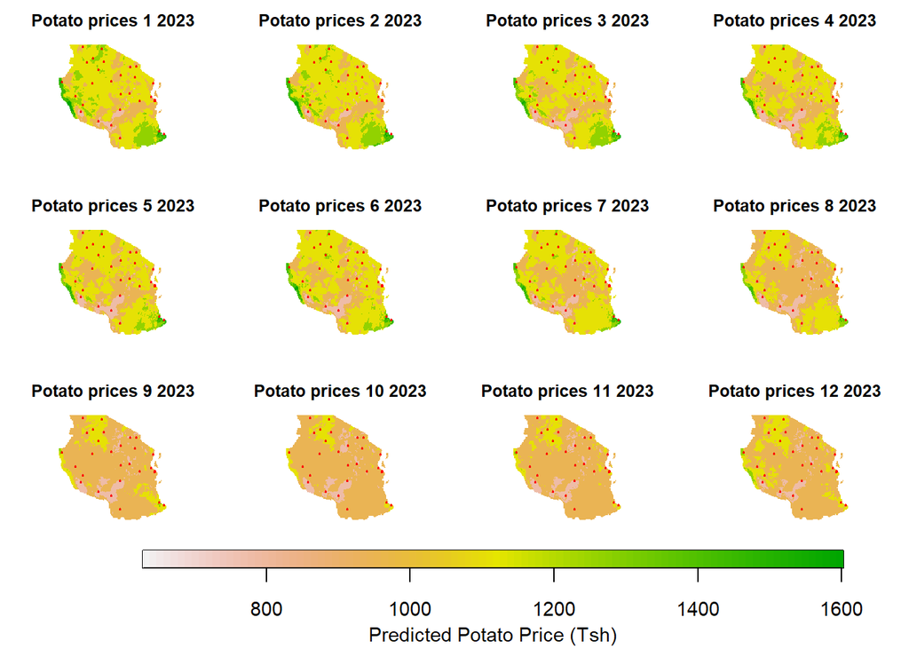

```r
#potatoes
# Function to predict potato prices for a given month
predict_for_potato <- function(month) {
  rain_sum_lag <- rstack3[paste0("2023-", sprintf("%02d", month), "-01_rain.sum.lag")]
  names(rain_sum_lag) <- "rain.sum.lag"

  newstack <- c(rstack, rain_sum_lag)

  const_potato <- data.frame(
    maize = 0, rice = 0, sorghum = 0, bmillet = 0, fmillet = 0, wheat = 0, beans = 0, potato = 1,
    Month = month,
    Year = year
  )

  pred <- predict(newstack, rf, const = const_potato, na.rm = TRUE)
  pred <- mask(pred, tza1)
  return(pred)
}

# Create predictions for all months
predictions_potato <- lapply(1:12, predict_for_potato)

# Extract pixel values from predictions_potato
potato_values <- unlist(lapply(predictions_potato, values))
min_potato <- min(potato_values, na.rm = TRUE)
max_potato <- max(potato_values, na.rm = TRUE)

# Define the continuous color palette and reverse it
color_palette <- rev(terrain.colors(100))

# Set up plot layout with an extra row for the legend
layout_matrix <- matrix(c(1, 2, 3, 4,
                          5, 6, 7, 8,
                          9, 10, 11, 12,
                          13, 13, 13, 13), nrow = 4, byrow = TRUE)

# Set up layout
layout(layout_matrix, heights = c(1, 1, 1, 0.5))

# Loop through each month to plot potato prices
break_interval <- 150
par(mar = c(0, 0, 0, 0))
for (i in 1:12) {
  plot(predictions_potato[[i]], main = paste("Potato prices", toupper(i), year),
       zlim = c(min_potato, max_potato), col = color_palette,
       breaks = seq(min_potato, max_potato, by = break_interval),
       legend = FALSE, axes = FALSE)
  points(training_data, pch = 20, col = "red", cex = 0.5)
}

# Generate pretty breaks for the legend
legend_breaks <- pretty(c(min_potato, max_potato), n = 5)  # Adjust n as needed

# Reset plot layout to 1x1 for the legend
layout(matrix(1))

# Set margins for the legend
par(mar = c(5, 4, 2, 1))
# Plot the legend in the bottom row, centered horizontally
image.plot(zlim = c(min_potato, max_potato), legend.only = TRUE,
           col = color_palette, horizontal = TRUE,
           legend.width = 0.7, legend.shrink = 0.9,
           axis.args = list(at = legend_breaks, labels = legend_breaks, cex.axis = 0.9),
           legend.args = list(text = "Predicted Potato Price (Tsh)", side = 1, line = 2, cex = 0.9))
```

## Prediction Evaluation

### 1. Using Validation data

```r
pred<-predict(object=rf, newdata=validation_data)
actual<-validation_data$pkg
result<-data.frame(actual=actual, predicted=pred)
```

```r
mse <- mean((actual - pred)^2, na.rm=TRUE)
paste('Mean Squared Error:', mse)
```

```
## [1] "Mean Squared Error: 142415.415093055"
```

```r
rmse <- sqrt(mse)
paste('Root Mean Squared error: ',mean(sqrt(rf$mse)))
```

[output not shown]

```r
#Save predicted & observed price
write.csv(result, "result.csv")
```

```r
#reading result.csv file (predicted vs observed)
rslt <- read.csv("result.csv", header=T)
print(names(rslt))
```

```
## [1] "X"         "actual"    "predicted"
```

```r
#RMSE predicting from rf - predicited vs observed
rf.rmse<-round(sqrt(mean( (rslt$actual-rslt$predicted)^2 , na.rm = TRUE )),2)
print(rf.rmse)
```

```
## [1] 377.38
```

```r
#R-square
rf.r2<-round(summary(lm(actual~predicted, rslt))$r.squared,2)
print(rf.r2)
```

```
## [1] 0.79
```

```r
range(actual)
```

```
## [1]  350 4050
```

```r
range(pred)
```

```
## [1]  619.2183 3241.6656
```

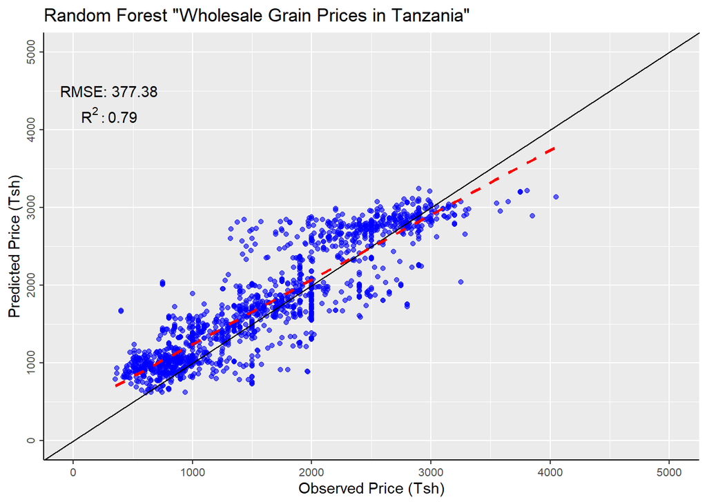

```r
#plotting predicted Vs observed
ggplot(result, aes(x=actual, y=predicted), alpha=0.6) +
  geom_point(colour = "blue", size = 1.4, alpha=0.6) +
  ggtitle('Random Forest "Wholesale Grain Prices in Tanzania"') +
  scale_x_continuous("Observed Price (Tsh)",
                     limits = c(0, 5000),
                     breaks = seq(0, 5000, 1000)) +
  scale_y_continuous("Predicted Price (Tsh)",
                     limits = c(0, 5000),
                     breaks = seq(0, 5000, 1000)) +
  theme(axis.line = element_line(colour = "black"),
        axis.text.y = element_text(size = 8, angle = 90, hjust = 0.5, vjust = 1),
        axis.text.x = element_text(size = 8)) +
  geom_abline(intercept = 0, slope = 1, linewidth = 0.5) +
  geom_smooth(aes(x = actual, y = predicted), formula = y ~ x, method = "lm", se = FALSE, colour = "red", linetype = 2, size = 0.9) +
  annotate("text", x = 300, y = 4500, label = paste("RMSE:", rf.rmse)) +
  annotate("text", x = 300, y = 4200, label = paste("R^2: ", rf.r2), parse = TRUE)
```

### 2. Compare the observed Prices (the training data) with the predicted Prices (predicted using the training data) using stats package

```r
library(stats)
```

```r
mypts_df$pred <- stats::predict(rf)
```

```r
rsq <- function (obs, pred) cor(obs, pred, use = 'complete.obs') ^ 2
RMSE <- function(obs, pred){sqrt(mean((pred - obs)^2, na.rm = TRUE))}
```

```r
fr2_rsq <- rsq(mypts_df$pkg, mypts_df$pred) %>% round(digits = 2)
fr2_rmse <- RMSE(mypts_df$pkg, mypts_df$pred) %>% round(digits = 0)
```

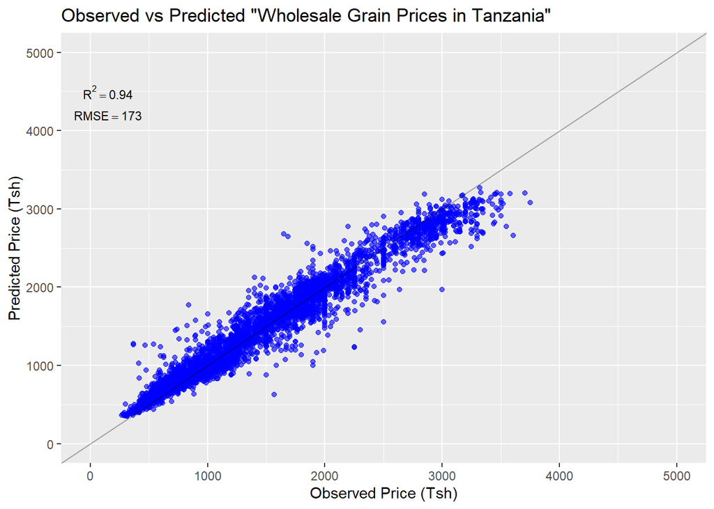

```r
Price_fit_plot <- ggplot(data = mypts_df, aes(x = pkg, y = pred)) +
  geom_point(colour = "blue", size = 1.4 ,alpha=0.6) +
  ggtitle('Observed vs Predicted "Wholesale Grain Prices in Tanzania"') +
  geom_abline(slope = 1, alpha=0.3) +
  annotate('text', x = 150, y = 4500, label = paste0("R^{2}==", fr2_rsq), parse = TRUE, size=3)  +
  annotate('text', x = 150, y = 4200, label = paste0("RMSE==", fr2_rmse), parse = TRUE, size=3)  +
  labs(x = "Observed Price (Tsh)", y = "Predicted Price (Tsh)") +
  xlim(0, 5000) + ylim(0, 5000)
Price_fit_plot
```

# Partial dependence plots

```r
library(caret)

var_importance <- varImp(rf)

impvar <- rownames(var_importance)[order(var_importance[, 1], decreasing=TRUE)]
```

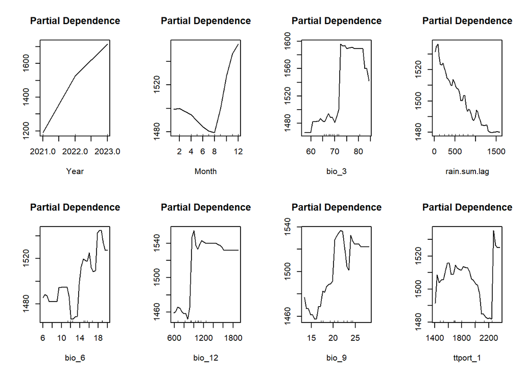

```r
op <- par(mfrow=c(2, 4))
# exclude food commodities and months
predictors_to_plot <- setdiff(impvar, c("maize", "rice", "sorghum", "bmillet", "fmillet", "wheat", "beans", "potato", "jan", "feb", "mar", "apr", "may", "jun", "jul", "aug", "sep", "oct", "nov", "dec"))

for (i in seq_along(predictors_to_plot)) {
  partialPlot(rf, as.data.frame(training_data), predictors_to_plot[i], xlab=predictors_to_plot[i],
              main="Partial Dependence")
}
```

## Summarize the price data by commodity

```r
# Determine the number of observations for each commodity
#After removing NAs
crop_counts <- table(mypts$Crop)
crop_counts
```

```
##
##    Maize     Rice  Sorghum B.Millet F.Millet    Wheat    Beans   Potato
##      859      858      705      559      731      535      854      832
```

```r
# Create a data frame with crop and count
crop_summary <- data.frame(
  Crop = names(crop_counts),
  Count = as.vector(crop_counts)
)
```

```r
# Print the crop summary
print(crop_summary)
```

```
##       Crop Count
## 1    Maize   859
## 2     Rice   858
## 3  Sorghum   705
## 4 B.Millet   559
## 5 F.Millet   731
## 6    Wheat   535
## 7    Beans   854
## 8   Potato   832
```

## correlation Plots

These are correlation plots for pooled sample in two periods: post-harvest (May-Oct) and lean season (Nov-April).

```r
#We'll use mean Monthly data in wide format
prices.monthly
```

```
##             Region     Market Month Year Latitude Longitude mai.price ric.price
##   1:        Arusha     Arusha     5 2021 -3.36968  36.68808  469.0000  1530.000
##   2: Dar es Salaam     Temeke     5 2021 -6.85097  39.25672  485.0000  1650.000
##   3:        Dodoma    Majengo     5 2021 -6.17971  35.74109  501.5000  1592.000
##   4:        Dodoma   Kibaigwa     5 2021 -6.08110  36.64645  375.0000       NaN
##   5:        Kagera     Bukoba     5 2021 -1.33140  31.81293  426.2500  1260.000
##  ---
## 860:        Mwanza     Mwanza     7 2024 -2.51969  32.90144  725.0000  2350.000
## 861:         Pwani      Pwani     7 2024 -6.44221  38.90622  835.7143  1946.429
## 862:        Simiyu    Bariadi     7 2024 -2.80355  33.98699  660.0000  1450.000
## 863:        Kigoma     Kigoma     7 2024 -4.89697  29.65987  578.5714  1417.857
## 864:         Rukwa Sumbawanga     7 2024 -7.95239  31.62319  546.7857  1653.571
##      sor.price bul.price fin.price whe.price bea.price pot.price
##   1:   695.000   761.000  1333.000  793.0000  1545.000  745.0000
##   2:   900.000   900.000  1775.000 1230.0000  2420.000  730.0000
##   3:   558.000   581.000  1752.000       NaN  2075.000  618.0000
##   4:   437.500       NaN       NaN       NaN       NaN       NaN
##   5:  1375.000  1337.500  1637.500 1637.5000  1300.000  675.0000
##  ---
## 860:  1428.571  1421.429  1621.429       NaN  2528.571 1142.8571
## 861:  1442.857  1550.000  1857.143 1975.0000  2967.857 1735.7143
## 862:  1400.000  1739.286  1728.571 2457.1429  2750.000 1500.0000
## 863:  1821.429  1892.857  1907.143 1867.8571  2228.571 1075.0000
## 864:       NaN       NaN   975.000  719.6429  2135.714  641.0714
```

```r
# Create a function to determine the season
get_season <- function(month) {
  if (month %in% 5:10) {
    return("Post-Harvest")
  } else {
    return("Lean Season")
  }
}
```

```r
# Add a 'Season' column to the data
prices.monthly$Season <- sapply(prices.monthly$Month, get_season)
```

```r
# Post Harvest Data
post_harvest_data <- prices.monthly[prices.monthly$Season == "Post-Harvest", ]
# Remove rows with NaNs from the Post-Harvest data
post_harvest_data <- post_harvest_data[complete.cases(post_harvest_data[, 7:14]), ]

# Lean Season data
lean_season_data <- prices.monthly[prices.monthly$Season == "Lean Season", ]
# Remove rows with NaNs from the Lean Season data
lean_season_data <- lean_season_data[complete.cases(lean_season_data[, 7:14]), ]
```

```r
# Calculate correlation matrix for Post-Harvest season
post_harvest_corr <- cor(post_harvest_data[, 3:14])
# Calculate correlation matrix for Lean Season
lean_season_corr <- cor(lean_season_data[, 3:14])
```

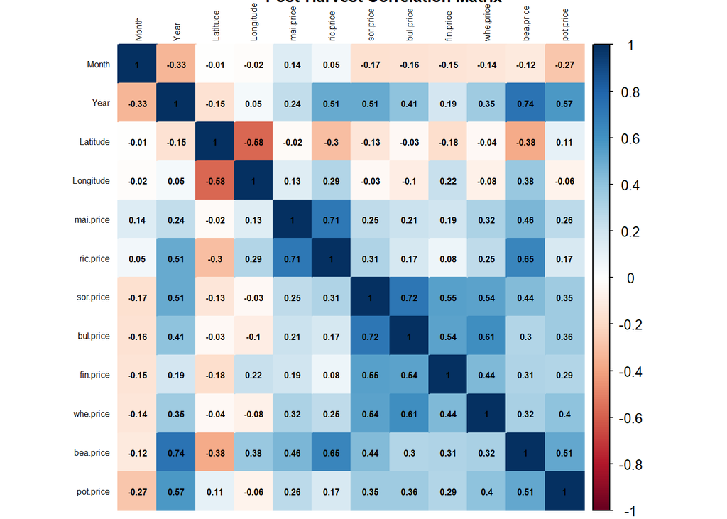

```r
# Plot correlation matrix for Post-Harvest season
corrplot(post_harvest_corr,
         method = "color",
         title = "",
         tl.col = "black",
         tl.cex = 0.5,
         addCoef.col = "black",
         number.cex = 0.5,
         number.digits = 2)

# Add title to the plot
title(main = "Post-Harvest Correlation Matrix",
      line = 4,
      cex.main = 0.9)
```

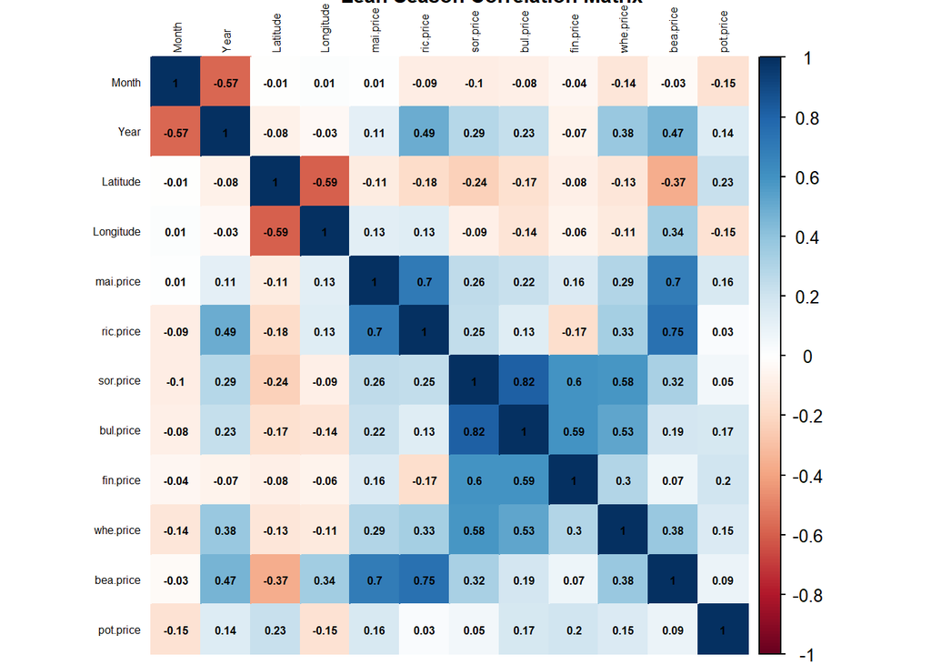

```r
# Plot correlation matrix for Lean Season
corrplot(lean_season_corr,
         method = "color",
         title = "",
         tl.col = "black",
         tl.cex = 0.5,
         addCoef.col = "black",
         number.cex = 0.5,
         number.digits = 2)

# Add title to the plot
title(main = "Lean Season Correlation Matrix",
      line = 4,
      cex.main = 0.9)
```

# Crop Specific Price Predictions

```r
# Filter data for maize
mypts_df2 <- as.data.frame(mypts)
mypts_maize <- mypts_df2[mypts_df2$Crop == "Maize", ]
unique(mypts_maize$Crop)
```

```
## [1] Maize
## Levels: Maize Rice Sorghum B.Millet F.Millet Wheat Beans Potato
```

```r
# Harmonize the levels
mypts_maize <- mypts_maize %>%
  mutate(Crop = as.character(Crop)) %>%
  mutate(Crop = factor(Crop))
# check again
unique(mypts_maize$Crop)
```

```
## [1] Maize
## Levels: Maize
```

```r
mypts_maize <- vect(mypts_maize, geom=c("Longitude", "Latitude"), crs=crs(tza0), keepgeom=TRUE)
```

```r
# Training data for maize
training_data_maize <- mypts_maize[mypts_maize$Year %in% c(2021, 2022, 2023), ]
# Filter the data for validation (Jan 2024 - July 2024)
validation_data_maize <- mypts_maize[mypts_maize$Year == 2024, ]
```

```r
# Fit the Random Forest Model
rf_maize <- randomForest(pkg ~ Month + Year + ttport_1 + bio_3 + bio_6 + bio_9 + bio_12 + rain.sum.lag,
                         data = training_data_maize,
                         na.rm = TRUE)

rf_maize
```

```
##
## Call:
##  randomForest(formula = pkg ~ Month + Year + ttport_1 + bio_3 +      bio_6 + bio_9 + bio_12 + rain.sum.lag, data = training_data_maize,      na.rm = TRUE)
##                Type of random forest: regression
##                      Number of trees: 500
## No. of variables tried at each split: 2
##
##           Mean of squared residuals: 12980.05
##                     % Var explained: 84.36
```

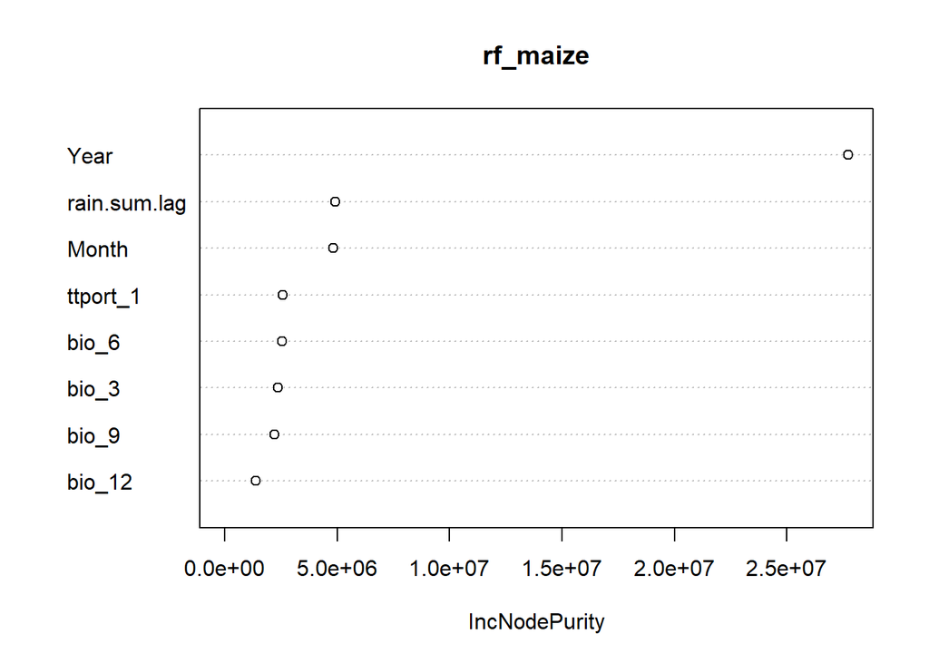

```r
# evaluate
varImpPlot(rf_maize)
```

### Prediction Evaluation Maize Only RF Model

We predict the validation data using the rf model then calculate R^2 and RMSE

```r
pred_maize<-predict(object=rf_maize, newdata=validation_data_maize)
actual_maize<-validation_data_maize$pkg
result_maize<-data.frame(actual=actual_maize, predicted=pred_maize)
```

```r
#Save predicted & observed yield
write.csv(result_maize, "result_maize.csv")

#reading result_maize.csv file (predicted vs observed)
rslt_m <- read.csv("result_maize.csv", header=T)
print(names(rslt_m))
```

```
## [1] "X"         "actual"    "predicted"
```

```r
#R-square predicting from rf_maize predicited vs observed
rf_maize.rmse<-round(sqrt(mean( (rslt_m$actual-rslt_m$predicted)^2 , na.rm = TRUE )),2)
print(rf_maize.rmse)
```

```
## [1] 325.47
```

```r
#R-square
rf_maize.r2<-round(summary(lm(actual~predicted, rslt_m))$r.squared,2)
print(rf_maize.r2)
```

```
## [1] 0.38
```

```r
#R-square
rf_maize.r2<-round(summary(lm(actual~predicted, rslt_m))$r.squared,2)
print(rf_maize.r2)
```

```
## [1] 0.38
```

```r
range(actual_maize)
```

```
## [1]  350 1250
```

```r
range(pred_maize, na.rm = TRUE)
```

```
## [1]  703.9585 1323.0264
```

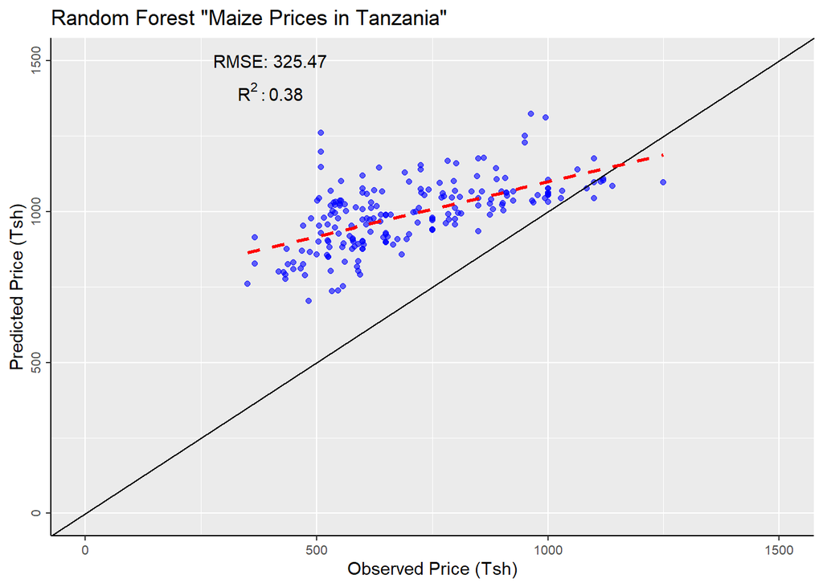

```r
#plotting predicted Vs observed
ggplot(result_maize, aes(x=actual_maize, y=pred_maize), alpha=0.6) +
  geom_point(colour = "blue", size = 1.4, alpha=0.6) +
  ggtitle('Random Forest "Maize Prices in Tanzania"') +
  scale_x_continuous("Observed Price (Tsh)",
                     limits = c(0, 1500),
                     breaks = seq(0, 1500, 500)) +
  scale_y_continuous("Predicted Price (Tsh)",
                     limits = c(0, 1500),
                     breaks = seq(0, 1500, 500)) +
  theme(axis.line = element_line(colour = "black"),
        axis.text.y = element_text(size = 8, angle = 90, hjust = 0.5, vjust = 1),
        axis.text.x = element_text(size = 8)) +
  geom_abline(intercept = 0, slope = 1, linewidth = 0.5) +
  geom_smooth(aes(x = actual, y = predicted), formula = y ~ x, method = "lm", se = FALSE, colour = "red", linetype = 2, size = 0.9) +
  annotate("text", x = 400, y = 1500, label = paste("RMSE:", rf_maize.rmse)) +
  annotate("text", x = 400, y = 1400, label = paste("R^2: ", rf_maize.r2), parse = TRUE)
```

## Beans Price Prediction

```r
# Filter data for Beans
mypts_beans <- mypts_df2[mypts_df2$Crop == "Beans", ]
unique(mypts_beans$Crop)
```

```
## [1] Beans
## Levels: Maize Rice Sorghum B.Millet F.Millet Wheat Beans Potato
```

```r
# Harmonize the levels
mypts_beans <- mypts_beans %>%
  mutate(Crop = as.character(Crop)) %>%
  mutate(Crop = factor(Crop))
# check again
unique(mypts_beans$Crop)
```

```
## [1] Beans
## Levels: Beans
```

```r
mypts_beans <- vect(mypts_beans, geom=c("Longitude", "Latitude"), crs=crs(tza0), keepgeom=TRUE)
```

```r
# Training data for beans
training_data_beans <- mypts_beans[mypts_beans$Year %in% c(2021, 2022, 2023), ]

# Validation Data beans
validation_data_beans <- mypts_beans[mypts_beans$Year == 2024, ]
```

```r
# Fit the Random Forest Model
rf_beans <- randomForest(pkg ~ Month + Year + ttport_1 + bio_3 + bio_6 + bio_9 + bio_12 + rain.sum.lag,
                         data = training_data_beans,
                         na.rm = TRUE)

rf_beans
```

```
##
## Call:
##  randomForest(formula = pkg ~ Month + Year + ttport_1 + bio_3 +      bio_6 + bio_9 + bio_12 + rain.sum.lag, data = training_data_beans,      na.rm = TRUE)
##                Type of random forest: regression
##                      Number of trees: 500
## No. of variables tried at each split: 2
##
##           Mean of squared residuals: 48290.36
##                     % Var explained: 85.92
```

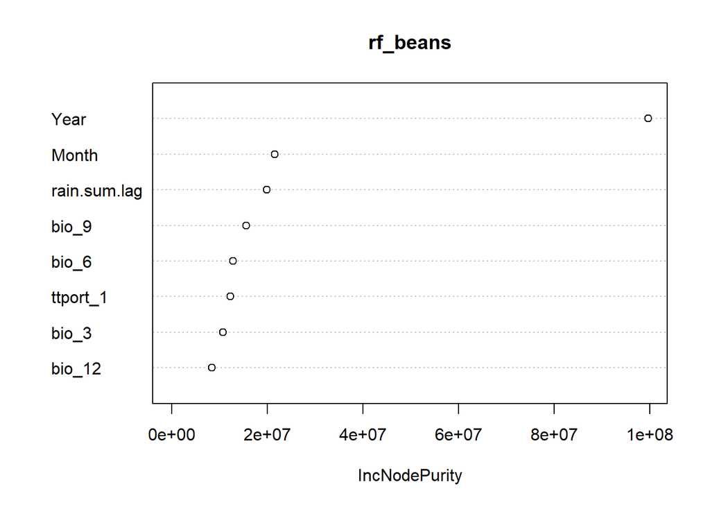

```r
# evaluate
varImpPlot(rf_beans)
```

### Prediction Evaluation Beans Only RF Model Using Validation data

```r
pred_beans<-predict(object=rf_beans, newdata=validation_data_beans)
actual_beans<-validation_data_beans$pkg
result_beans<-data.frame(actual=actual_beans, predicted=pred_beans)
```

```r
#Save predicted & observed beans price
write.csv(result_beans, "result_beans.csv")
```

```r
#reading result_beans.csv file (predicted vs observed)
rslt_b <- read.csv("result_beans.csv", header=T)
print(names(rslt_b))
```

```
## [1] "X"         "actual"    "predicted"
```

```r
#R-square predicting from rf_beans predicited vs observed
rf_beans.rmse<-round(sqrt(mean( (rslt_b$actual-rslt_b$predicted)^2 , na.rm = TRUE )),2)
print(rf_beans.rmse)
```

```
## [1] 348.32
```

```r
#R-square
rf_beans.r2<-round(summary(lm(actual~predicted, rslt_b))$r.squared,2)
print(rf_beans.r2)
```

```
## [1] 0.38
```

```r
range(actual_beans)
```

```
## [1] 1252.5 3850.0
```

```r
range(pred_beans)
```

```
## [1] 1868.940 3287.237
```

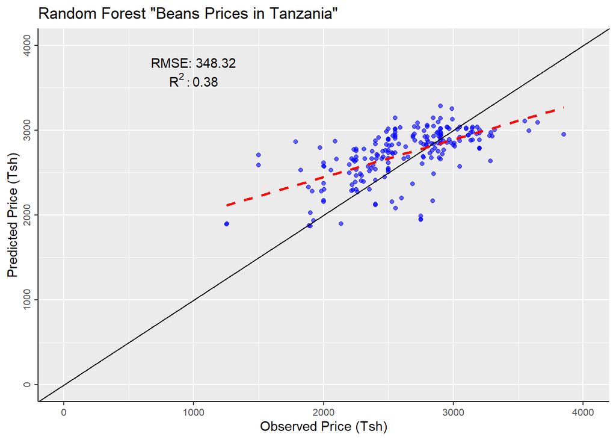

```r
#plotting predicted Vs observed Beans Prices
ggplot(result_beans, aes(x=actual_beans, y=pred_beans), alpha=0.6) +
  geom_point(colour = "blue", size = 1.4, alpha=0.6) +
  ggtitle('Random Forest "Beans Prices in Tanzania"') +
  scale_x_continuous("Observed Price (Tsh)",
                     limits = c(0, 4000),
                     breaks = seq(0, 4000, 1000)) +
  scale_y_continuous("Predicted Price (Tsh)",
                     limits = c(0, 4000),
                     breaks = seq(0, 4000, 1000)) +
  theme(axis.line = element_line(colour = "black"),
        axis.text.y = element_text(size = 8, angle = 90, hjust = 0.5, vjust = 1),
        axis.text.x = element_text(size = 8)) +
  geom_abline(intercept = 0, slope = 1, linewidth = 0.5) +
  geom_smooth(aes(x = actual, y = predicted), formula = y ~ x, method = "lm", se = FALSE, colour = "red", linetype = 2, size = 0.9) +
  annotate("text", x = 1000, y = 3800, label = paste("RMSE:", rf_beans.rmse)) +
  annotate("text", x = 1000, y = 3600, label = paste("R^2: ", rf_beans.r2), parse = TRUE)
```

## Rice Price Prediction

```r
# Filter data for Rice
mypts_rice <- mypts_df2[mypts_df2$Crop == "Rice", ]
unique(mypts_rice$Crop)
```

```
## [1] Rice
## Levels: Maize Rice Sorghum B.Millet F.Millet Wheat Beans Potato
```

```r
# Harmonize the levels
mypts_rice <- mypts_rice %>%
  mutate(Crop = as.character(Crop)) %>%
  mutate(Crop = factor(Crop))
# check again
unique(mypts_rice$Crop)
```

```
## [1] Rice
## Levels: Rice
```

```r
mypts_rice <- vect(mypts_rice, geom=c("Longitude", "Latitude"), crs=crs(tza0), keepgeom=TRUE)
```

```r
# Training data for rice
training_data_rice <- mypts_rice[mypts_rice$Year %in% c(2021, 2022, 2023), ]

# Validation Data rice
validation_data_rice <- mypts_rice[mypts_rice$Year == 2024, ]
```

```r
# Fit the Random Forest Model
rf_rice <- randomForest(pkg ~ Month + Year + ttport_1 + bio_3 + bio_6 + bio_9 + bio_12 + rain.sum.lag,
                         data = training_data_rice,
                         na.rm = TRUE)

rf_rice
```

```
##
## Call:
##  randomForest(formula = pkg ~ Month + Year + ttport_1 + bio_3 +      bio_6 + bio_9 + bio_12 + rain.sum.lag, data = training_data_rice,      na.rm = TRUE)
##                Type of random forest: regression
##                      Number of trees: 500
## No. of variables tried at each split: 2
##
##           Mean of squared residuals: 38862.74
##                     % Var explained: 89.9
```

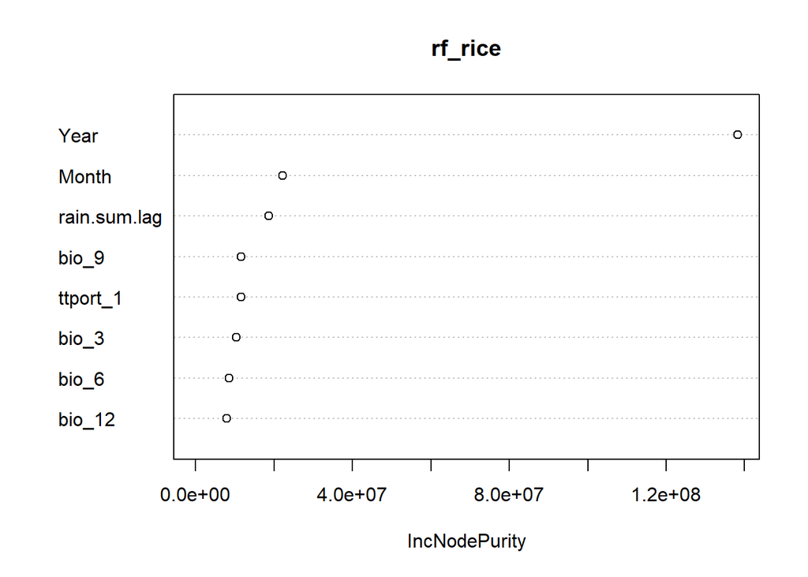

```r
# evaluate
varImpPlot(rf_rice)
```

### Prediction Evaluation Rice Only RF Model Using Validation data

```r
pred_rice<-predict(object=rf_rice, newdata=validation_data_rice)
actual_rice<-validation_data_rice$pkg
result_rice<-data.frame(actual=actual_rice, predicted=pred_rice)
```

```r
#Save predicted & observed rice price
write.csv(result_rice, "result_rice.csv")
```

```r
#reading result_rice.csv file (predicted vs observed)
rslt_r <- read.csv("result_rice.csv", header=T)
print(names(rslt_r))
```

```
## [1] "X"         "actual"    "predicted"
```

```r
#R-square predicting from rf_rice predicited vs observed
rf_rice.rmse<-round(sqrt(mean( (rslt_r$actual-rslt_r$predicted)^2 , na.rm = TRUE )),2)
print(rf_rice.rmse)
```

```
## [1] 480.29
```

```r
#R-square
rf_rice.r2<-round(summary(lm(actual~predicted, rslt_r))$r.squared,2)
print(rf_rice.r2)
```

```
## [1] 0.29
```

```r
range(actual_rice)
```

```
## [1] 1316.667 3010.000
```

```r
range(pred_rice)
```

```
## [1] 1898.561 3101.155
```

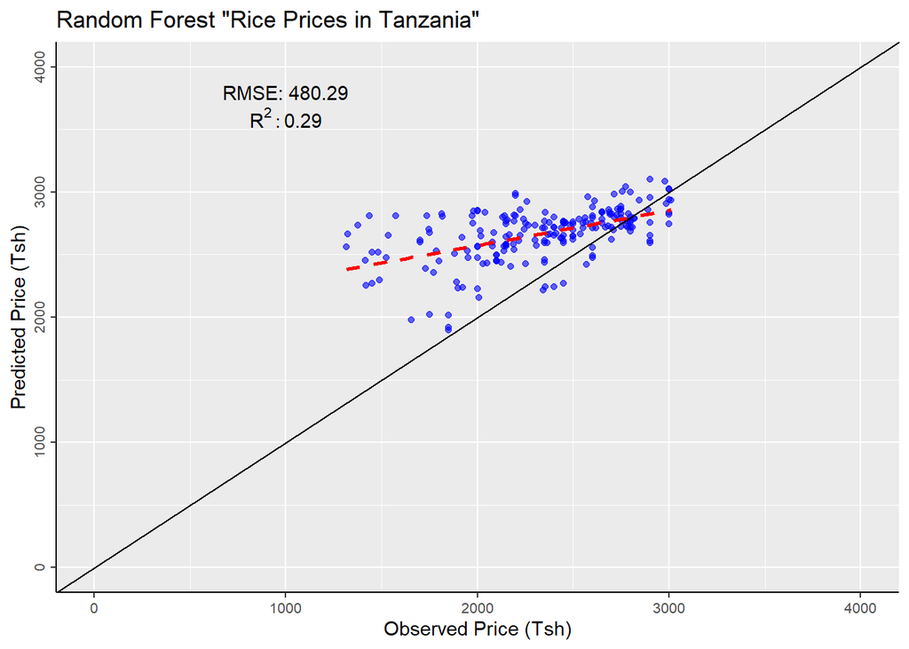

```r
#plotting predicted Vs observed Rice Prices
ggplot(result_rice, aes(x=actual_rice, y=pred_rice), alpha=0.6) +
  geom_point(colour = "blue", size = 1.4, alpha=0.6) +
  ggtitle('Random Forest "Rice Prices in Tanzania"') +
  scale_x_continuous("Observed Price (Tsh)",
                     limits = c(0, 4000),
                     breaks = seq(0, 4000, 1000)) +
  scale_y_continuous("Predicted Price (Tsh)",
                     limits = c(0, 4000),
                     breaks = seq(0, 4000, 1000)) +
  theme(axis.line = element_line(colour = "black"),
        axis.text.y = element_text(size = 8, angle = 90, hjust = 0.5, vjust = 1),
        axis.text.x = element_text(size = 8)) +
  geom_abline(intercept = 0, slope = 1, linewidth = 0.5) +
  geom_smooth(aes(x = actual, y = predicted), formula = y ~ x, method = "lm", se = FALSE, colour = "red", linetype = 2, size = 0.9) +
  annotate("text", x = 1000, y = 3800, label = paste("RMSE:", rf_rice.rmse)) +
  annotate("text", x = 1000, y = 3600, label = paste("R^2: ", rf_rice.r2), parse = TRUE)
```